{% raw %}

# 10. Milestone Project 3: Time series forecasting in TF (BitPredict)

### What is a time series problem?

They deal with data overtime, such as staff members in a company over a 10-year basis, sales computer for the past 5 years, etc.

Timeline can either be short by seconds/minutes, or long like months/years - problems used to investigate can be broken down into two categories.

[figure not shown]

Both these cases demand supervised learning approach, where the example data has a label associated with it.

For example with bitcoing, the data could be the past month, and the label could be today's price (tomorrow/future price is what we're predicting).

We've got a lot to go through.

- Get time series data (the historical price of Bitcoin)
  - Load in time series data using pandas/Python's CSV module
- Format data for a time series problem
  - Creating training and test sets (the wrong way)
  - Creating training and test sets (the right way)
  - Visualizing time series data
  - Turning time series data into a supervised learning problem (windowing)
  - Preparing univariate and multivariate (more than one variable) data
- Evaluating a time series forecasting model
- Setting up a series of deep learning modelling experiments
  - Dense (fully-connected) networks
  - Sequence models (LSTM and 1D CNN)
  - Ensembling (combining multiple models together)
  - Multivariate models
  - Replicating the N-BEATS algorithm using TensorFlow layer subclassing
- Creating a modelling checkpoint to save the best performing model during training
- Making predictions (forecasts) with a time series model
- Creating prediction intervals for time series model forecasts
- Discussing two different types of uncertainty in machine learning (data uncertainty and model uncertainty)
- Demonstrating why forecasting in an open system is BS (the turkey problem)

### Get data

We'll need to gatehr bitcoin price data, from 01 October 2013, to 18 May 2021.

Our start date is 01/10/2013 cuz of our data source `Coindesk` started recording the price of bitcoin from then. However, the source of data does not allow any exporting (as we now live in the age of un-user friendly subscription hell), we will use a `csv` file provided from this workbook, that has the data.

```python
# Download Bitcoin historical data from GitHub
# Note: you'll need to select "Raw" to download the data in the correct format
import urllib.request

url = "https://raw.githubusercontent.com/mrdbourke/tensorflow-deep-learning/main/extras/BTC_USD_2013-10-01_2021-05-18-CoinDesk.csv "
filename = "bitcoin_data"

urllib.request.urlretrieve(url, filename)
```

```
('bitcoin_data', <http.client.HTTPMessage at 0x232d3290490>)
```

### Importing time series data with pandas

With our csv data, we can import it using pandas and visualize it with `read_csv()`.

Because our data has the `date` component, we also want to tell pandas to parse the dates with `parse_dates` parameter into our date column.

```python
# import with pandas
import pandas as pd
# parse dates and set date column to index
df = pd.read_csv('bitcoin_data.csv',
                 parse_dates=['Date'],
                 index_col=['Date']) # parse date column (to tell pandas 1st column is datetime)
df.head()
```

| Date | Currency | Closing Price (USD) | 24h Open (USD) | 24h High (USD) | 24h Low (USD) |
| --- | --- | --- | --- | --- | --- |
| 2013-10-01 | BTC | 123.65499 | 124.30466 | 124.75166 | 122.56349 |
| 2013-10-02 | BTC | 125.45500 | 123.65499 | 125.75850 | 123.63383 |
| 2013-10-03 | BTC | 108.58483 | 125.45500 | 125.66566 | 83.32833 |
| 2013-10-04 | BTC | 118.67466 | 108.58483 | 118.67500 | 107.05816 |
| 2013-10-05 | BTC | 121.33866 | 118.67466 | 121.93633 | 118.00566 |

```python
df.info()
```

```
<class 'pandas.core.frame.DataFrame'>
DatetimeIndex: 2787 entries, 2013-10-01 to 2021-05-18
Data columns (total 5 columns):
 #   Column               Non-Null Count  Dtype
---  ------               --------------  -----
 0   Currency             2787 non-null   object
 1   Closing Price (USD)  2787 non-null   float64
 2   24h Open (USD)       2787 non-null   float64
 3   24h High (USD)       2787 non-null   float64
 4   24h Low (USD)        2787 non-null   float64
dtypes: float64(4), object(1)
memory usage: 130.6+ KB
```

Since we told pandas to parse the date column and set it as the index, the date column details does not such up in the list of columns - in addition, there aren't many samples either.

### Types of time series

[figure not shown]

*Example of different kinds of patterns you'll see in time series data. Notice the bottom right time series has little to no patterns, making prediction difficult.*

Deep learning algorithms usually flourish with lots of data, in the range of thousands to millions of data points.

We only have daily prices, making max 365/366 samples per year.

For simplicity sake, let's remove some of the columns, so we only have the date and closing price.

```python
# only want closing price for each day
bitcoin_prices =pd.DataFrame(df['Closing Price (USD)']).rename(columns={'Closing Price (USD)':'Price'})
bitcoin_prices.head()
```

| Date | Price |
| --- | --- |
| 2013-10-01 | 123.65499 |
| 2013-10-02 | 125.45500 |
| 2013-10-03 | 108.58483 |
| 2013-10-04 | 118.67466 |
| 2013-10-05 | 121.33866 |

Much better!

But that's only five days worth Bitcoin prices, let's plot everything we've got

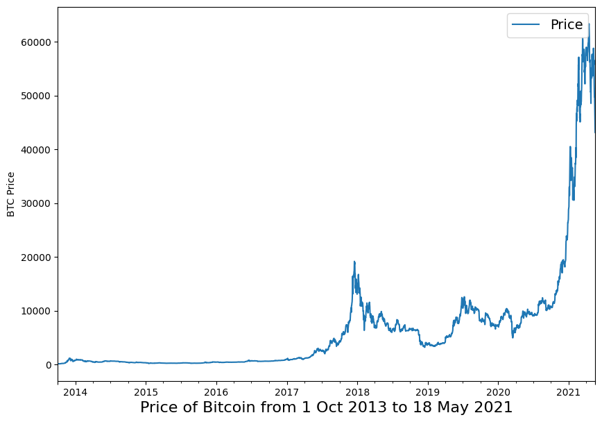

```python
import matplotlib.pyplot as plt

bitcoin_prices.plot(figsize=(10,7))
plt.ylabel('BTC Price')
plt.xlabel('Price of Bitcoin from 1 Oct 2013 to 18 May 2021',fontsize=16)
plt.legend(fontsize=14);
```

### Importing time series data with Python's CSV module

Let's try replicate the graph above but with Python's `csv` and `datetime` modules.

```python
# importing and formatting historical bitcoin data with python
import csv
from datetime import datetime

timesteps=[]
btc_price=[]
with open('bitcoin_data.csv','r') as f:
    csv_reader = csv.reader(f,delimiter=',') # read in the target csv
    next(csv_reader) # skip first line (as it is column titles)
    for line in csv_reader:
        timesteps.append(datetime.strptime(line[1],'%Y-%m-%d')) # get data as dates (not as strings), strptime = string parse time (aka proper time obj for model)
        btc_price.append(float(line[2])) # get the closing price as float

# view first 10 of each
timesteps[:10],btc_price[:10]
```

```
([datetime.datetime(2013, 10, 1, 0, 0),
  datetime.datetime(2013, 10, 2, 0, 0),
  datetime.datetime(2013, 10, 3, 0, 0),
  datetime.datetime(2013, 10, 4, 0, 0),
  datetime.datetime(2013, 10, 5, 0, 0),
  datetime.datetime(2013, 10, 6, 0, 0),
  datetime.datetime(2013, 10, 7, 0, 0),
  datetime.datetime(2013, 10, 8, 0, 0),
  datetime.datetime(2013, 10, 9, 0, 0),
  datetime.datetime(2013, 10, 10, 0, 0)],
 [123.65499,
  125.455,
  108.58483,
  118.67466,
  121.33866,
  120.65533,
  121.795,
  123.033,
  124.049,
  125.96116])
```

Let's check it as a plot

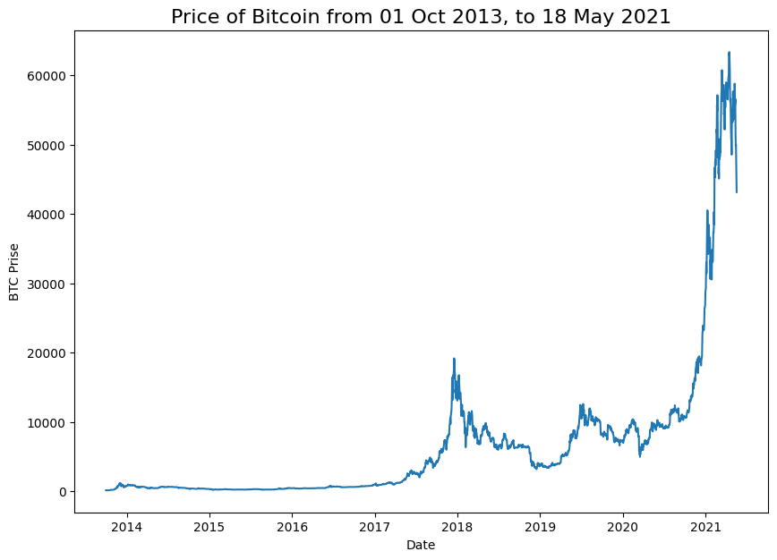

```python
# plot from csv
import matplotlib.pyplot as plt
import numpy as np
plt.figure(figsize=(10,7))
plt.plot(timesteps,btc_price)
plt.title('Price of Bitcoin from 01 Oct 2013, to 18 May 2021', fontsize=16)
plt.xlabel('Date')
plt.ylabel('BTC Prise');
```

### Format Data Part 1: Creating train and test sets for time series data

Let's prepeare our data for the model, by splitting it into a test train split. However the typical `train_test_split()` from Scikit learn is not applicable for time series. More specifically `univariate`, and `multivariate` data.

- **Univariate** time series data works with one variable - e.g. past price of Bitcoin, predicts the future price of Bitcoin.
- **Multivariate** time series data with more than one variable - e.g. electricity demand using time in the day, and number of houses in the region.

[figure not shown]

#### Create train and test sets for time series in the *wrong* way

We are using the univariate time series, so we only need to train test split one variable (rather than multitude for multivariate).

Let's try the wrong way of splitting data - first we'll turn the dataframe index and column into np arrays.

```python
# get bitcoin date array
timesteps = bitcoin_prices.index.to_numpy()
prices = bitcoin_prices['Price'].to_numpy()

timesteps[:10],prices[:10]
```

```
(array(['2013-10-01T00:00:00.000000000', '2013-10-02T00:00:00.000000000',
        '2013-10-03T00:00:00.000000000', '2013-10-04T00:00:00.000000000',
        '2013-10-05T00:00:00.000000000', '2013-10-06T00:00:00.000000000',
        '2013-10-07T00:00:00.000000000', '2013-10-08T00:00:00.000000000',
        '2013-10-09T00:00:00.000000000', '2013-10-10T00:00:00.000000000'],
       dtype='datetime64[ns]'),
 array([123.65499, 125.455  , 108.58483, 118.67466, 121.33866, 120.65533,
        121.795  , 123.033  , 124.049  , 125.96116]))
```

Time to `train_test_split` it

```python
# wrong way to split for time series
from sklearn.model_selection import train_test_split

X_train,X_test,y_train,y_test = train_test_split(timesteps, # dates
                                                 prices, # prices
                                                 test_size=0.2,
                                                 random_state=35)

X_train.shape,X_test.shape,y_train.shape,y_test.shape
```

```
((2229,), (558,), (2229,), (558,))
```

So it splits correctly, but what about visually?

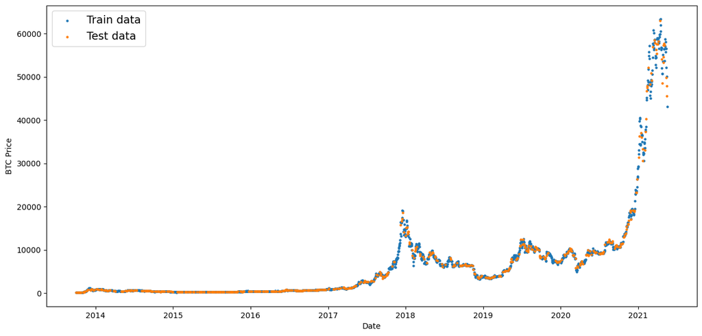

```python
# plot the train test split data
plt.figure(figsize=(15,7))
plt.scatter(X_train,y_train,s=5,label='Train data')
plt.scatter(X_test,y_test,s=5,label='Test data')
plt.xlabel('Date')
plt.ylabel('BTC Price')
plt.legend(fontsize=14)
plt.show();
```

You can tell how unhelpful this time series data split is - with time being a crucial component to model training, this split removes all elements of being able to use time to predict something in the future, because the examples are all spread out and isolated from each other.

So for this to work, we would need to split our training to reflect the past, and the test to reflect the future.

#### Create train and test sets the right way

We would have to establish a point in time where everything before the point, is our training data, and anything after the point is considered our test data.

[figure not shown]

```python
# Create train and test splits the right way for time series data
split_size = int(0.8*len(prices))

# create train data splits (everything before the split)
X_train,y_train = timesteps[:split_size],prices[:split_size]

# Create test data splits (everything after the split)
X_test,y_test = timesteps[split_size:],prices[split_size:]

len(X_train),len(X_test),len(y_train),len(y_test)
```

```
(2229, 558, 2229, 558)
```

Let's again visualize

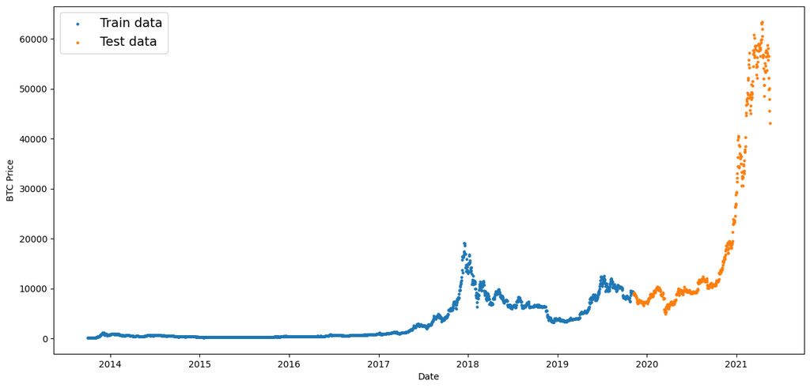

```python
# plot the train test split data
plt.figure(figsize=(15,7))
plt.scatter(X_train,y_train,s=5,label='Train data')
plt.scatter(X_test,y_test,s=5,label='Test data')
plt.xlabel('Date')
plt.ylabel('BTC Price')
plt.legend(fontsize=14)
plt.show();
```

Perfect, now we can use the past, to predicted a simulated future (where we have the actual data to gauge the model's theoretical performance on future data).

#### Create a plotting function

Rather than retyping `matplotlib` commands to plot the same graph, we'll make a plotting function for continuous reuse.

```python
# create a function to plot time series data
def plot_time_series(timesteps,values,format='.',start=0,end=None,label=None):
    '''
    Plots timestep against values (e.g. bitcoin price over time)

    Parameters:
    timesteps = array of timesteps
    values = array of values across time
    format = style of plot, default '.'
    start = where to start the plot (setting value will index from start of timesteps and values)
    end = where to end the plot (setting value will index from end of timesteps and values)
    label = label to show on plot of values
    '''
    # plot the series
    plt.plot(timesteps[start:end],values[start:end],format,label=label)
    plt.xlabel('Time')
    plt.ylabel('BTC Price')
    if label:
        plt.legend(fontsize=14) # make  label bigger
    plt.grid(True)
```

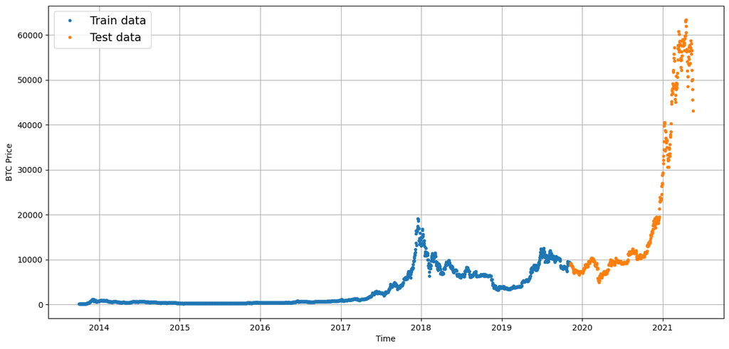

```python
# try our plotting function
plt.figure(figsize=(15,7))
plot_time_series(timesteps=X_train,values=y_train,label='Train data')
plot_time_series(timesteps=X_test,values=y_test,label='Test data')
```

### Model experiments

We can build any model for our problem, as long as input and outputs are formatted correctly. But just because we can build anything, doesn't mean we should.

Before running experiments, let's familiarise these two terms: **horizon** and **window**.

- **horizon** = number of timesteps to predict into future
- **window** = number of timesteps from the past to be used for prediction of **horizon**

E.g. if we wanted to predict tomorrow's bitcoin price, using the previous week's worth of prices, the horizon = 1, and window = 7

We will perform the following experiments:

| Model Number | Mode Type | Horizon size | Window size | Extra data |
| --- | --- | --- | --- | --- |
| 0 | Naïve model (baseline) | NA | NA | NA |
| 1 | Dense model | 1 | 7 | NA |
| 2 | Same as 1 | 1 | 30 | NA |
| 3 | Same as 1 | 7 | 30 | NA |
| 4 | Conv1D | 1 | 7 | NA |
| 5 | LSTM | 1 | 7 | NA |
| 6 | Same as 1 (but with multivariate data) | 1 | 7 | Block reward size |
| 7 | N-BEATs Algorithm | 1 | 7 | NA |
| 8 | Ensemble (multiple models optimized on different loss functions) | 1 | 7 | NA |
| 9 | Future prediction model (model to predict future values) | 1 | 7 | NA |
| 10 | Same as 1 (but with turkey 🦃 data introduced) | 1 | 7 | NA |

### Model 0: Naive forecast (baseline)

Let's start with a model that requires no training at all, as a baseline.

The model does prediction as:

The prediction at timstep `t`, is equal to the value at timestep `t-1` (previous timestep.)

With an open system like stock market, trying to beat the naive forecast with any other model is difficult.

> 🔑 Note: For the sake of this notebook, an open system is a system where inputs and outputs can freely flow, such as a market (stock or crypto). Where as, a closed system the inputs and outputs are contained within the system (like a poker game with your buddies, you know the buy in and you know how much the winner can get). Time series forecasting in open systems is generally quite poor.

```python
# create a naive forecast
naive_forecast = y_test[:-1] # naive forecast equals every value excluding the last value
naive_forecast[:10],naive_forecast[-10:] # view first and last 10
```

```
(array([9226.48582088, 8794.35864452, 8798.04205463, 9081.18687849,
        8711.53433917, 8760.89271814, 8749.52059102, 8656.97092235,
        8500.64355816, 8469.2608989 ]),
 array([57107.12067189, 58788.20967893, 58102.19142623, 55715.54665129,
        56573.5554719 , 52147.82118698, 49764.1320816 , 50032.69313676,
        47885.62525472, 45604.61575361]))
```

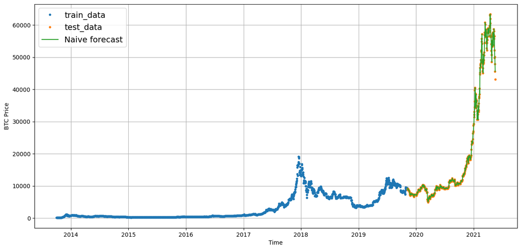

```python
# plot naive forecast
plt.figure(figsize=(15,7))
plot_time_series(timesteps=X_train,values=y_train,label='train_data')
plot_time_series(timesteps=X_test,values=y_test,label='test_data')
plot_time_series(timesteps=X_test[1:],values=naive_forecast,format='-',label='Naive forecast')
```

Pretty obvious the data is following well, when we practically copy pasted `y_test` over to it but delayed by `1` timestep.

Let's zoom in and have a better gander. This can be done by offsetting value and passing it to the `start` param from out `plot_time_series()` function.

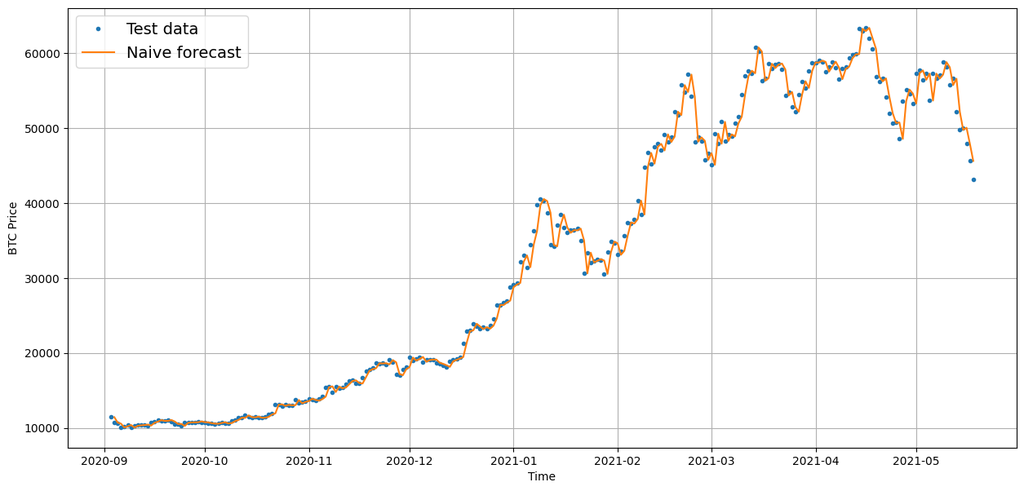

```python
plt.figure(figsize=(15,7))
offset = 300 # offset the values by 300 integers
plot_time_series(timesteps=X_test,values=y_test,start=offset,label='Test data')
plot_time_series(timesteps=X_test[1:],values=naive_forecast,format='-',start=offset,label='Naive forecast')
```

Zooming in, we can tell the offset between naive forecast and test data, as our naive baseline model is simply predicting the previous timestep, by returning the same value as said previous timestep.

Time to evaluate it.

### Evaluating a time series model

We use regression evaluation metrics on the prediction data, as it involves our model predicting numbers. Our main evaluation is, how does `y_preds` compare against `y_test`.

#### Scale dependent errors

These are the metrics which can be used to compare time series alues and forecasts that are on the same scale. For example, Bitcoin historical prices in USD, versus Bitcoin forecast values in USD.

| Metric | Details | Code |
| --- | --- | --- |
| MAE (mean absolute error) | Easy to interpret (a forecast is X amount different from actual amount). Forecast methods which minimises the MAE will lead to forecasts of the median. | tf.keras.metrics.mean_absolute_error() |
| RMSE (root mean square error) | Forecasts which minimise the RMSE lead to forecasts of the mean. | tf.sqrt(tf.keras.metrics.mean_square_error()) |

#### Percentage errors

Percentage errors do not have units, this means they can be used to compare forecasts across different datasets.

| Metric | Details | Code |
| --- | --- | --- |
| MAPE (mean absolute percentage error) | Most commonly used percentage error. May explode (not work) if y=0. | tf.keras.metrics.mean_absolute_percentage_error() |
| sMAPE (symmetric mean absolute percentage error) | Recommended not to be used by Forecasting: Principles and Practice, though it is used in forecasting competitions. | Custom implementation |

#### Scaled errors

Scaled errors are an alternative to percentage errors when comparing forecast performance across different time series.

| Metric | Details | Code |
| --- | --- | --- |
| MASE (mean absolute scaled error). | MASE equals one for the naive forecast (or very close to one). A forecast which performs better than the naïve should get <1 MASE. | See sktime's mase_loss() |

With so many evaluation options and evaluating a lot of model, we'll write a function to help us calculate evaluation metrics on their forecasts.

```python
# add tf
import tensorflow as tf
```

Unfortunately tensorflow doesn't have a readily made `MASE`, so let's build our own version.

```python
# implement mase
def mean_absolute_scaled_error(y_true,y_pred):
    '''
    Implement MASE (assuming no seasonality of data)
    '''
    mae = tf.reduce_mean(tf.abs(y_true-y_pred)) # reduce mean computes the average(mean) value - our example is calculating absolute difference of average mean

    # find mae of naive forecast (no seasonality)
    mae_naive_no_season = tf.reduce_mean(tf.abs(y_true[1:] - y_true[:-1])) # our seasonality is 1 day (which is why it shifts by 1)
    # essentially the above is the mean absolute difference, and finding that number from our naive model.

    return mae / mae_naive_no_season
```

Our case above, we're taking a model prediction's MAE, and comparing it to the MAE value produced by baseline naive model.

In practice, if function is created correctly, the naive model should achieve an MASE of 1 (or close to it). Any model worse than it will achieve >1, and better is <1.

Let's put our different evaluation metrics together into a function.

```python
def evaluate_preds(y_true,y_pred):
    # make sure float32 (for metric calculations)
    y_true = tf.cast(y_true,dtype=tf.float32)
    y_pred = tf.cast(y_pred,dtype=tf.float32)

    # calculate various metrics
    mae = tf.keras.metrics.mean_absolute_error(y_true,y_pred)
    mse = tf.keras.metrics.mean_squared_error(y_true,y_pred) # puts an emphasis on outliers (all errors get squared)
    rmse = tf.sqrt(mse)
    mape = tf.keras.metrics.mean_absolute_percentage_error(y_true,y_pred)
    mase = mean_absolute_scaled_error(y_true,y_pred)

    return {'mae':mae.numpy(),
            'mse':mse.numpy(),
            'rmse':rmse.numpy(),
            'mape':mape.numpy(),
            'mase':mase.numpy(),}
```

Let's now test it on our naive forecast :)

```python
naive_results = evaluate_preds(y_true=y_test[1:],
                               y_pred=naive_forecast)
naive_results
```

[output not shown]

[output cut: 402 more lines]

[output not shown]

Based on MAE, it looks like our average forecast is ~$567 different than the actual Bitcoin prise.

How does that compare to the average price of Bitcoin in the test dataset?

```python
# find average bitcoin price
tf.reduce_mean(y_test).numpy()
```

```
20056.632963737226
```

Knowing that the average price of bitcoin is $20,056, and the naive forecast is off by $567, does that tell us that this is a good enough model?

That's up to personal interpretation - my thoughts is that it's not at all good, as the first half of the data, the price of bitcoin barely changed, versus the latter half where its volatility really shows. So relatively, it had a cheat sheet of the first half of the data.

#### Other kinds of time series forecasting models which can be used for baselines and actual forecasts

There are a few different models that can be tried as a naive baseline model.

Some of them may even perform better than the best performing one in this notebook - this can be trialed as extra cirricular.

[output not shown]

### Format data part 2: Windowing dataset

Windowing is a method to turn a time series dataset into **supervised learning problem**. Basically, we want windows of the past to predict the future.

For a univariate time series, windowing one week (`window=7`) to predict the next single value (`horizon=1`) might look like:

```
Window for one week (univariate time series)

[0, 1, 2, 3, 4, 5, 6] -> [7]
[1, 2, 3, 4, 5, 6, 7] -> [8]
[2, 3, 4, 5, 6, 7, 8] -> [9]
```

Or for the price of Bitcoin, it'd look like:

```
Window for one week with the target of predicting the next day (Bitcoin prices)

[123.654, 125.455, 108.584, 118.674, 121.338, 120.655, 121.795] -> [123.033]
[125.455, 108.584, 118.674, 121.338, 120.655, 121.795, 123.033] -> [124.049]
[108.584, 118.674, 121.338, 120.655, 121.795, 123.033, 124.049] -> [125.961]
```

[figure not shown]

Let's build some functions which take in a univariate time series, turn it into windows and horizons of specified sizes.

We'll start with the default horizon size of 1 and a window size of 7 (these are random starting values to try).

```python
HORIZON = 1
WINDOW_SIZE = 7
```

Now we'll write a function to take in an array and turn it into a window and horizon.

```python
# create function to label windowed data
def get_labelled_window(x,horizon=1):
    '''
    Creates labels for windowed dataset.add

    E.g. if horizon = 1 (default)
    Input: [1,2,3,4,5,6] -> Output: ([1,2,3,4,5],[6])
    '''
    return x[:,:-horizon], x[:,-horizon:]
```

```python
# test out the window labelling function
test_window, test_label = get_labelled_window(tf.expand_dims(tf.range(8) + 1 , axis = 0), horizon=HORIZON)
print(f'Window: {tf.squeeze(test_window).numpy()} -> Label: {tf.squeeze(test_label).numpy()}')
```

```
Window: [1 2 3 4 5 6 7] -> Label: 8
```

> But why use 2D vector instead of 1D?

Notice how we have an extra dim accompanied in the function, and how we `tf.expand_dims` our `tf.range(8)`? Well this is intentional, as remember, that empty dimension outside the range of number is for the model to store `batch_number`. Without that extra dims, the model throws an error, as it expects it when trained on. Having those batches allow the model see a multitude of samples at once, rather than individual slices, which can compromise training.

> What is axis = 0 doing?

It contributes to `tf.expand_dims`, by telling the computer *where* to add the new dimension - by stating 0, it'll apply it as the first column leaving `[1,8]`. Whilst `axis=1` will give `[8,1]`.

Now we just need to do that over the entire dataset. We could use loops, but that's very slow and inefficient.

For speed, we can use Numpy's array indexing. Let's write a function as:

1. Creates a window step of specific window size, for example: [[0,1,2,3,4,5,6,7]]
2. Uses NumPy indexing to create a 2D of multiple window steps, for example:

```
[[0, 1, 2, 3, 4, 5, 6, 7],
 [1, 2, 3, 4, 5, 6, 7, 8],
 [2, 3, 4, 5, 6, 7, 8, 9]]
```

3. Uses the 2D array of multiple window steps to index on a target series
4. Uses the `get_labelled_windows()` function we created above to turn the window steps into windows with a specified horizon.

```python
# create function to view numpy arrays as windows
def make_windows(x,window_size=7,horizon=1):
    '''
    Turns a 1D array into a 2D array of sequential windows of window_size
    '''
    # 1. Create a window of window_size (add the horizon on the end for later labelling)
    window_step = np.expand_dims(np.arange(window_size+horizon), axis=0)
    # this gives the size needed for model to start sorting it - e.g. 8 with 7 + 1  (window + horizon)
    # print(f'Window step:\n {window_step}')

    # 2. Create a 2D array of multiple window steps (minus 1 to account for 0 indexing)
    window_indexes = window_step + np.expand_dims(np.arange(len(x) - (window_size + horizon - 1)), axis = 0).T # create 2D array of window of window_size
    # create dimensions as long as the length of our data (minus our window size except horizon due to index starting at 0)
    # this is to accomodate for ALL 7 window sized data, which needs to fit in this 2 dims data.
    # .T -> swaps rows and columns arround (A,B) -> (B,A)

    # a = np.array([[1,2,3],
    #               [2,3,4]])
    # Turns to:
    # [[1,2],
    #  [2,3],
    #  [3,4]]

    # This way, our indexed windows is by column designation rather than row - meaning we can still check bitcoin price by reading the top row, rather than interpreting it by column.

    # 3. Index on the target array (time series) with 2D array of multiple window steps
    windowed_array = x[window_indexes]
    # By providing the index locale of the window, our bitcoin price will add the pricing value to the 2-dim window, based on the index location provided.

    # 4. Get the labelled windows
    windows, labels = get_labelled_window(windowed_array, horizon=horizon)

    return windows, labels
```

```python
full_windows,full_labels = make_windows(prices,window_size=WINDOW_SIZE,horizon=HORIZON)
len(full_windows),len(full_labels)
```

```
(2780, 2780)
```

Sweet, let's begin visualizing

```python
# view the last 3 windows/labels
for i in range(3):
    print(f'Window: {full_windows[i-3]} -> Label: {full_labels[i-3]}')
```

```
Window: [58788.20967893 58102.19142623 55715.54665129 56573.5554719
 52147.82118698 49764.1320816  50032.69313676] -> Label: [47885.62525472]
Window: [58102.19142623 55715.54665129 56573.5554719  52147.82118698
 49764.1320816  50032.69313676 47885.62525472] -> Label: [45604.61575361]
Window: [55715.54665129 56573.5554719  52147.82118698 49764.1320816
 50032.69313676 47885.62525472 45604.61575361] -> Label: [43144.47129086]
```

```python
# view the first 3 windows/labels
for i in range(3):
    print(f'Window: {full_windows[i]} -> Label: {full_labels[i]}')
```

```
Window: [123.65499 125.455   108.58483 118.67466 121.33866 120.65533 121.795  ] -> Label: [123.033]
Window: [125.455   108.58483 118.67466 121.33866 120.65533 121.795   123.033  ] -> Label: [124.049]
Window: [108.58483 118.67466 121.33866 120.65533 121.795   123.033   124.049  ] -> Label: [125.96116]
```

### Turning windows into training and test sets

We could have windowed our training and test sets as well. However it usually works better to window the data first, then split it into training and test sets.

Let's write a function which takes in full sets of windows and their labels, then splits into train and test data.

```python
# make the train/test splits
def make_train_test_splits(windows,labels,test_split=0.2):
    '''
    Splits matching pairs of windows and labels into train and test splits.
    '''
    split_size = int(len(windows)*(1-test_split)) # splitting our full window set of `2780` into 80/20
    train_windows = windows[:split_size]
    train_labels = labels[:split_size]
    test_windows = windows[split_size:]
    test_labels = labels[split_size:]
    return train_windows, test_windows, train_labels, test_labels
```

Let's test it!

```python
train_windows,test_windows,train_labels,test_labels = make_train_test_splits(full_windows,full_labels)
len(train_windows), len(test_windows), len(train_labels), len(test_labels)
```

```
(2224, 556, 2224, 556)
```

Let's also check the first 5 samples

```python
train_windows[:5],train_labels[:5]
```

```
(array([[123.65499, 125.455  , 108.58483, 118.67466, 121.33866, 120.65533,
         121.795  ],
        [125.455  , 108.58483, 118.67466, 121.33866, 120.65533, 121.795  ,
         123.033  ],
        [108.58483, 118.67466, 121.33866, 120.65533, 121.795  , 123.033  ,
         124.049  ],
        [118.67466, 121.33866, 120.65533, 121.795  , 123.033  , 124.049  ,
         125.96116],
        [121.33866, 120.65533, 121.795  , 123.033  , 124.049  , 125.96116,
         125.27966]]),
 array([[123.033  ],
        [124.049  ],
        [125.96116],
        [125.27966],
        [125.9275 ]]))
```

```python
# check to see if its the same (accounting for horizon and window size)
np.array_equal(np.squeeze(train_labels[:-HORIZON-1]),y_train[WINDOW_SIZE:])
```

```
True
```

### Make a modelling checkpoint

We're in a territory where performance will fluctuate, regardless of epoch of the model - so we will need to checkpoint the best performing model, and compare it with the other best performers.

We will implement a `ModelCheckpoint` callback.

The `ModelCheckpoint` callback will monitor our model's performance during training, and save the best model to file by setting `save_best_only=True`.

That way we can still evaluate model by its best configuration.

Because we're running multiple experiments, it makes sense to keep track of them by saving models to file under different names.

We'll write a function called `ModelCheckpoint` callback which saves a model to specified filename.

```python
import os
# create a function to implement a ModelCheckpoint callback with a specific filename
def create_model_checkpoint(model_name, save_path='model_experiments'):
    return tf.keras.callbacks.ModelCheckpoint(filepath=os.path.join(save_path,model_name), # create filepath to save model
                                              verbose=0, # only output a limited amount of text
                                              save_best_only=True) # save only the best model to file
```

## Model 1: Dense model (window = 7, horizon = 1)

Model 1 is kept simple, and will have the following:

- A single dense layer with 128 hidden units and ReLU activation
- An output layer with linear activation (or no activation)
- Adam optimizer and MAE loss function
- Batch size of 128
- 100 epochs

Why these values? For experimentation purposes so no patterns lol.

Let's import TensorFlow and build our first deep learning model for time series.

```python
import tensorflow as tf
from tensorflow.keras import layers

# set random seed for reproducible results
tf.random.set_seed(35)

# construct model
model_1 = tf.keras.Sequential([
    layers.Dense(128,activation='relu'),
    layers.Dense(HORIZON,activation='linear') # linear activation is the same as no activation
], name='model_1_dense') # give the model a name so we can save it

# compile model
model_1.compile(loss='mae',
                optimizer=tf.keras.optimizers.Adam(),
                metrics=['mae']) # we don't nessecarily need this when the loss function is MAE by default

# fit model
model_1.fit(x=train_windows, # train windows of 7 timesteps of Bitcoin prices
            y=train_labels, # horizon value of 1 (using prev 7 timesteps to predict it)
            epochs=100,
            verbose=1,
            batch_size=128,
            validation_data=(test_windows,test_labels),
            callbacks=[create_model_checkpoint(model_name=model_1.name)]) # create ModelCheckpoint callback to save best model
```

[output not shown]

[output not shown]

[output not shown]

[output not shown]

[output not shown]

[output not shown]

[output not shown]

[output not shown]

[output not shown]

[output not shown]

[output not shown]

[output not shown]

[output not shown]

[output not shown]

[output not shown]

[output not shown]

[output not shown]

[output not shown]

[output not shown]

[output not shown]

[output not shown]

[output not shown]

[output not shown]

[output not shown]

[output not shown]

[output not shown]

[output not shown]

[output not shown]

[output not shown]

[output not shown]

[output not shown]

[output not shown]

[output not shown]

```
<keras.src.callbacks.History at 0x1d027985870>
```

Training was fast cuz there's not a lot of data. Let's evaluate it.

```python
# evaluate model on test data
model_1.evaluate(test_windows,test_labels)
```

```
[680.1854248046875, 680.1854248046875]
```

The model achieves very similarly to the valuation data to test, cuz we used both val and test as the same dataset.

Let's load in `model_1` instead, saved from our `ModelCheckpoint` callback, and we should see an improvement of results.

```python
# Load in saved best performing model_1 and evaluate on test data
model_1 = tf.keras.models.load_model('model_experiments/model_1_dense')
model_1.evaluate(test_windows,test_labels)
```

```
[564.8428955078125, 564.8428955078125]
```

Slight improvement boost :)

### Making forecasts with a model (on the test dataset)

With more modelling experiments, let's write a function which:

- 1. Takes in a trained model (just like `model_1`)
- 2. Takes in some input data (just like the data the model was trained on)
- 3. Passes the input data to the model's `predict()` method
- 4. Returns the predictions

```python
def make_preds(model,input_data):
    '''
    Uses model to make predictions on input_data

    Parameters:

    model - trained model
    input_data - windowed input

    returns model predictions on input_data.
    '''
    forecast = model.predict(input_data)
    return tf.squeeze(forecast) # return 1D array of predictions
```

```python
# make predictions using model_1 on the test dataset and view the results
model_1_preds = make_preds(model_1,test_windows)
len(model_1_preds), model_1_preds[:10]
```

```
(556,
 <tf.Tensor: shape=(10,), dtype=float32, numpy=
 array([8846.008, 8794.023, 9044.992, 8745.695, 8774.071, 8771.338,
        8663.746, 8524.818, 8481.52 , 8532.625], dtype=float32)>)
```

Now we've got some prediction values, let's use the `evaluate_preds()` we created before to compare them to the ground truth.

```python
# evaluate preds
model_1_results = evaluate_preds(y_true=tf.squeeze(test_labels), # reduce to right shape
                                 y_pred=model_1_preds)
model_1_results
```

```
{'mae': 564.84296,
 'mse': 1150266.8,
 'rmse': 1072.5049,
 'mape': 2.5312698,
 'mase': 0.9922726}
```

Let's check it against naive forecast.

```python
naive_results
```

```
{'mae': 567.9802,
 'mse': 1147547.0,
 'rmse': 1071.2362,
 'mape': 2.5165248,
 'mase': 0.99957}
```

Let's use the `plot_time_series()` function to plot `model_1_preds` against the test data.

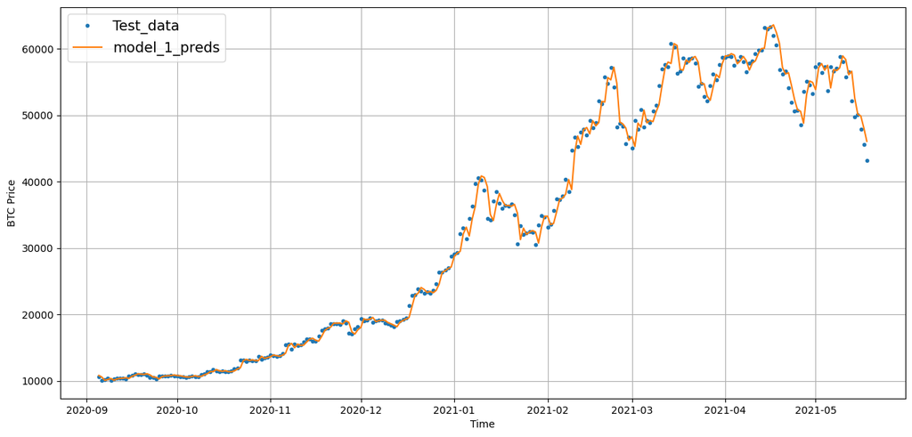

```python
offset = 300
plt.figure(figsize=(15,7))

# account for the test_window offset and index into test_labels to ensure correct plotting
plot_time_series(timesteps=X_test[-len(test_windows):], values=test_labels[:,0], start=offset, label='Test_data')
plot_time_series(timesteps=X_test[-len(test_windows):], values=model_1_preds, start=offset, format='-', label='model_1_preds')
```

```python
-len(test_windows)
```

```
-556
```

FYI on the -len(test_windows), we're getting the length of the test window from our predictions. And to achieve that, we're going the *other* way around, so we using the negative to get the last data point, to the data point of whenever test_window length ends.

In addition, [:,0] tells the model to grab the first row where our test labels set - as our `test_label` has an extra dim, making it 2D.

### Model 2: Dense (windows = 30, horizon = 1)

We'll keep the same model architecture as `model_1` but try it with a window of 30 instead. (Using 30 days of past bitcoin data to predict tomorrow's price).

[figure not shown]

We can start preparing the model experiment, by making the datasets with the functions that were created earlier.

```python
HORIZON = 1
WINDOW_SIZE = 30
```

```python
# make windowed data, with hyperparameters established above
full_windows,full_labels = make_windows(prices,window_size=WINDOW_SIZE,horizon=HORIZON)
len(full_windows),len(full_labels)
```

```
(2757, 2757)
```

```python
# Make train and testing windows
train_windows, test_windows, train_labels, test_labels = make_train_test_splits(windows=full_windows,labels=full_labels)
len(train_windows),len(test_windows),len(train_labels),len(test_labels)
```

```
(2205, 552, 2205, 552)
```

Time to construct `model_2`. It will reuse the same architecture as `model_1`, and same training, to compare how window size change prediction.

```python
tf.random.set_seed(35)

# create model, same as model_1
model_2 = tf.keras.Sequential([
    layers.Dense(128,activation='relu'),
    layers.Dense(HORIZON) # to predict 'x' amount of steps into the future (aka HORIZON value)
], name='model_2_dense')

model_2.compile(loss='mae',
                optimizer=tf.keras.optimizers.Adam())

model_2.fit(train_windows,train_labels,
            epochs=100,batch_size=128,
            verbose=0,
            validation_data=(test_windows,test_labels),
            callbacks=[create_model_checkpoint(model_name=model_2.name)])
```

[output not shown]

[output not shown]

[output not shown]

[output not shown]

[output not shown]

[output not shown]

[output not shown]

[output not shown]

[output not shown]

[output not shown]

[output not shown]

[output not shown]

[output not shown]

[output not shown]

[output not shown]

[output not shown]

[output not shown]

[output not shown]

[output not shown]

[output not shown]

[output not shown]

[output not shown]

[output not shown]

[output not shown]

[output not shown]

[output not shown]

[output not shown]

[output not shown]

[output not shown]

[output not shown]

[output not shown]

[output not shown]

[output not shown]

[output not shown]

[output not shown]

[output not shown]

[output not shown]

[output not shown]

[output not shown]

[output not shown]

[output not shown]

[output not shown]

```
<keras.src.callbacks.History at 0x232996fb580>
```

Let's evaluate the performance

```python
# evaluate model 2 preds
model_2.evaluate(test_windows,test_labels)
```

```
919.2557373046875
```

Let's then try loading in the ebst saved with `ModelCheckpoint`

```python
# load in the best performing model
model_2 = tf.keras.models.load_model('model_experiments/model_2_dense/')
model_2.evaluate(test_windows,test_labels)
```

```
589.4548950195312
```

Seems like the model has not performed any better than `Model_1`, let's check full performance and make a comparison.

```python
# get forecast predictions
model_2_preds = make_preds(model_2, input_data=test_windows)
```

```python
# evaluate results for model_2
model_2_results = evaluate_preds(y_true=tf.squeeze(test_labels),
                                 y_pred=model_2_preds)
model_2_results
```

```
{'mae': 589.4548,
 'mse': 1239025.9,
 'rmse': 1113.1154,
 'mape': 2.644404,
 'mase': 1.0303727}
```

Model_1 performance:

[output not shown]

This also means the model also doesn't do any better than our naive model. Let's also visualize the prediction graph as well.

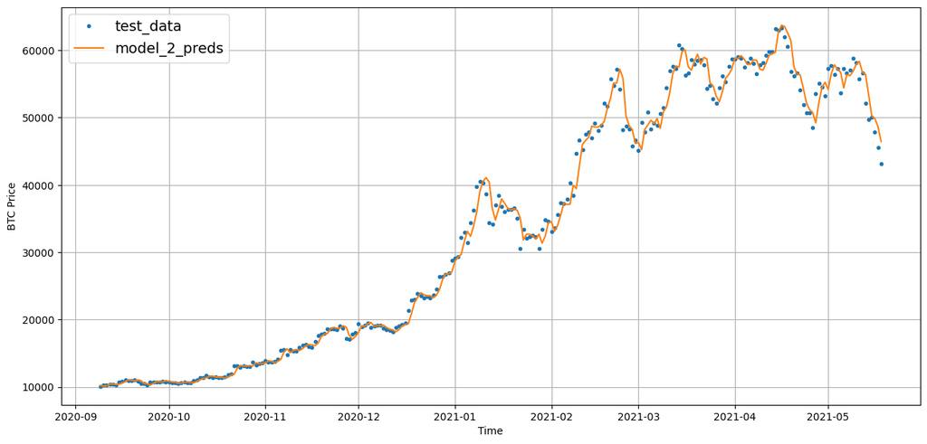

```python
offset = 300
plt.figure(figsize=(15,7))
# account for the test_window offset
plot_time_series(timesteps=X_test[-len(test_windows):], values=test_labels[:,0], start=offset, label='test_data')
plot_time_series(timesteps=X_test[-len(test_windows):], values=model_2_preds, start=offset, format='-', label='model_2_preds')
```

### Model 3: Dense (window = 30, horizon = 7)

Let's try and predict 7 day ahead given the previous 30 days.

Again the same architecture and training, only changing the `HORIZON` and `WINDOW_SIZE`.

```python
HORIZON = 7
WINDOW_SIZE = 30

full_windows, full_labels = make_windows(prices, window_size=WINDOW_SIZE, horizon=HORIZON)
len(full_windows), len(full_labels)
```

```
(2751, 2751)
```

And we'll split the full dataset windows into training and test sets.

```python
train_windows,test_windows,train_labels,test_labels = make_train_test_splits(windows=full_windows,labels=full_labels,test_split=0.2)
len(train_windows), len(test_windows), len(train_labels), len(test_labels)
```

```
(2200, 551, 2200, 551)
```

Now let's build, compile, fit and evaluate said model.

```python
tf.random.set_seed(35)

# create model - same arch of model_1
model_3 = tf.keras.Sequential([
    layers.Dense(128, activation='relu'),
    layers.Dense(HORIZON)
], name='model_3_dense')

model_3.compile(loss='mae',
                optimizer=tf.keras.optimizers.Adam())

model_3.fit(train_windows,train_labels,
            batch_size=128,epochs=100,
            verbose=0,
            validation_data=(test_windows,test_labels),
            callbacks=[create_model_checkpoint(model_name=model_3.name)])
```

[output not shown]

[output not shown]

[output not shown]

[output not shown]

[output not shown]

[output not shown]

[output not shown]

[output not shown]

[output not shown]

[output not shown]

[output not shown]

[output not shown]

[output not shown]

[output not shown]

[output not shown]

[output not shown]

[output not shown]

[output not shown]

[output not shown]

[output not shown]

[output not shown]

[output not shown]

[output not shown]

[output not shown]

[output not shown]

[output not shown]

[output not shown]

[output not shown]

[output not shown]

[output not shown]

[output not shown]

[output not shown]

[output not shown]

[output not shown]

[output not shown]

[output not shown]

[output not shown]

[output not shown]

[output not shown]

[output not shown]

[output not shown]

[output not shown]

[output not shown]

[output not shown]

[output not shown]

[output not shown]

[output not shown]

[output not shown]

```
<keras.src.callbacks.History at 0x232996fbd60>
```

Time to evaluate again and compare predictions.

```python
# model evaluation
model_3.evaluate(test_windows,test_labels)
```

```
1384.297119140625
```

```python
# load in best performing of
model_3 = tf.keras.models.load_model('model_experiments/model_3_dense')
model_3.evaluate(test_windows,test_labels)
```

```
1246.83935546875
```

Our errors are way higher than the previous models, mostly because we're predicting 7 values in the future, rather than just one. So the values further from it, will compound and more likely to give larger differences.

```python
# predictions are going to be 7 steps at a time
model_3_preds = make_preds(model_3,test_windows)
model_3_preds[:3]
```

```
<tf.Tensor: shape=(3, 7), dtype=float32, numpy=
array([[9403.457, 9413.834, 9374.856, 9316.454, 9516.926, 9342.037,
        9403.269],
       [9177.762, 9260.131, 9159.263, 9233.002, 9246.559, 9138.856,
        9238.119],
       [9086.021, 9135.112, 8998.206, 9254.245, 9248.125, 9078.625,
        9199.075]], dtype=float32)>
```

```python
# calculate model 3 results - these will be multidimensional, due to predicting more than one step at a time.
model_3_results = evaluate_preds(y_true=tf.squeeze(test_labels),
                                 y_pred=model_3_preds)
model_3_results
```

```
{'mae': array([ 602.6183  ,  456.4145  ,  438.4859  ,  628.0753  ,  433.6027  ,
         362.53802 ,  435.25543 ,  567.02435 ,  565.817   ,  574.21985 ,
         800.8879  ,  794.2198  ,  869.0767  ,  866.79285 ,  602.8919  ,
         285.25836 ,  216.06766 ,  251.41637 ,  210.06975 ,  214.7657  ,
         170.45326 ,  177.20055 ,  391.56027 ,  441.67865 ,  322.96283 ,
         167.23215 ,  186.82576 ,  130.91037 ,  171.84201 ,  214.51326 ,
         380.595   ,  506.75238 ,  457.6169  ,  461.88266 ,  411.07672 ,
         356.91656 ,  385.3095  ,  291.63727 ,  202.43115 ,  205.65848 ,
         422.11517 ,  141.44803 ,   73.541504,   77.04694 ,  108.87765 ,
         151.65256 ,   60.794155,  105.43262 ,  103.656944,  158.61258 ,
          94.764786,  146.7618  ,  204.5632  ,  224.84717 ,  241.23933 ,
         351.82108 ,  432.95236 ,  456.15366 ,  491.73828 ,  542.67084 ,
         387.90668 ,  214.7583  ,  276.61832 ,  385.0731  ,  382.41342 ,
         449.15897 ,  467.69733 ,  526.9196  ,  152.90514 ,  150.59738 ,
         211.66504 ,  393.2239  ,  628.4976  ,  433.29535 ,  331.57687 ,
         348.03543 ,  376.05078 ,  402.4025  ,  527.0766  ,  726.18317 ,
         743.6544  ,  574.34265 ,  276.67368 ,  174.3284  ,  185.90514 ,
         222.60574 ,  248.476   ,  318.72836 ,  363.83176 ,  531.67706 ,
         488.5445  ,  434.7288  ,  362.95355 ,  249.95131 ,  205.49637 ,
         244.18205 ,  348.62598 ,  575.5159  ,  609.42676 ,  743.852   ,
         539.7536  ,  328.30426 ,  181.30957 ,  381.26645 ,  379.23633 ,
         419.54868 ,  495.1646  ,  703.4195  ,  935.2638  , 1019.1593  ,
         866.2884  ,  481.04868 ,  179.61984 ,  219.96736 ,  243.6709  ,
         298.69342 ,  351.05365 ,  444.9388  ,  559.689   , 1111.0056  ,
        1772.1239  , 2221.879   , 2234.8198  , 2166.1155  , 2406.991   ,
        2566.3945  , 1274.3795  ,  647.03467 ,  518.65924 ,  519.0928  ,
         767.5379  ,  632.8171  ,  775.1195  ,  331.0849  ,  256.25168 ,
         214.48291 ,  304.72525 ,  335.2973  ,  291.6901  ,  378.22488 ,
         286.48227 ,  367.95535 ,  743.48425 ,  911.8412  ,  822.9092  ,
         937.57806 ,  793.99347 ,  446.35254 ,  129.85051 ,  164.64977 ,
         173.19643 ,  310.37347 ,  482.94476 ,  556.0971  ,  517.16345 ,
         161.73682 ,  148.0136  ,  218.22307 ,  236.92892 ,  183.08084 ,
         275.42725 ,  210.82951 ,  219.45432 ,  244.30135 ,  252.10184 ,
         334.2313  ,  528.75195 ,  642.7544  ,  559.01825 ,  655.92633 ,
         836.9634  ,  910.2437  ,  924.1732  , 1068.0686  ,  470.28824 ,
         285.45648 ,  326.9866  ,  376.41098 ,  365.81836 ,  509.8623  ,
         495.6462  ,  502.64243 ,  675.09503 ,  830.7794  ,  791.1581  ,
         280.72836 ,  504.56836 ,  570.99304 ,  317.5805  ,  207.27385 ,
         224.72502 ,  276.25977 ,  324.46512 ,  543.66547 ,  685.1494  ,
         747.4185  ,  357.93246 ,  228.4926  ,  253.19518 ,  362.03363 ,
```

[output cut: 444 more lines]

```
        10.6977825 , 10.717593  , 11.068881  ,  7.6144805 ,  5.1798635 ,
         2.7393293 ,  2.3288605 ,  3.4522393 ,  6.4265175 ,  3.509615  ,
         3.94825   ,  7.494394  ,  7.4370213 ,  8.182476  ,  9.407095  ,
         9.576325  ,  4.911358  ,  3.3336124 ,  3.6630924 ,  6.951516  ,
         6.3390307 ,  4.225084  ,  4.8689046 ,  3.194065  ,  0.9977483 ,
         1.2264254 ,  2.2242773 ,  3.1601243 ,  1.6588798 ,  1.5118073 ,
         1.7764313 ,  2.8691096 ,  4.4241266 ,  4.990921  ,  4.7460027 ,
         2.9693935 ,  3.3304577 ,  5.0777435 ,  6.4546995 , 10.087419  ,
        13.91737   , 15.950911  , 16.193329  , 12.624004  , 10.340805  ,
         9.433291  ,  5.7189054 ,  4.079861  ,  5.4806495 ,  7.402555  ,
        10.026922  ,  6.621895  ,  2.9955463 ,  2.9217362 ,  3.6906686 ,
         1.6991694 ,  3.181275  ,  2.5708227 ,  2.9567327 ,  2.136917  ,
         3.0653152 ,  4.481051  ,  7.0392423 , 12.254608  , 16.993656  ,
        19.240076  ], dtype=float32),
 'mase': 2.2186804}
```

### Make our evaluation function work for larger horizons

Because our previous prediction does 7 steps at a time, we'll need to fix up `evaluate_preds()` function to work with multiple shapes of data.

```python
def evaluate_preds(y_true,y_pred):
    # make sure float 32 for calculation
    y_true = tf.cast(y_true,dtype=tf.float32)
    y_pred = tf.cast(y_pred,dtype=tf.float32)

    # calculate various metrics
    mae = tf.keras.metrics.mean_absolute_error(y_true,y_pred)
    mse = tf.keras.metrics.mean_squared_error(y_true,y_pred)
    rmse = tf.sqrt(mse)
    mape = tf.keras.metrics.mean_absolute_percentage_error(y_true,y_pred)
    mase = mean_absolute_scaled_error(y_true,y_pred)

    # account for different sized horizons
    if mae.ndim > 0: # if mae is not 1dim, then mean out the total values present
        mae = tf.reduce_mean(mae)
        mse = tf.reduce_mean(mse)
        rmse = tf.reduce_mean(rmse)
        mape = tf.reduce_mean(mape)
        mase = tf.reduce_mean(mase)

    return {'mae': mae.numpy(),
            'mse': mse.numpy(),
            'rmse': rmse.numpy(),
            'mape': mape.numpy(),
            'mase': mase.numpy()}
```

Now evaluation function is updates to include multi dim horizons, let's see how things look.

```python
# get model_3 results from evaluation function
model_3_results = evaluate_preds(y_true=tf.squeeze(test_labels),
                                 y_pred=model_3_preds)
model_3_results
```

```
{'mae': 1246.8394,
 'mse': 5340244.5,
 'rmse': 1427.0901,
 'mape': 5.669521,
 'mase': 2.2186804}
```

Now let's visualize the model

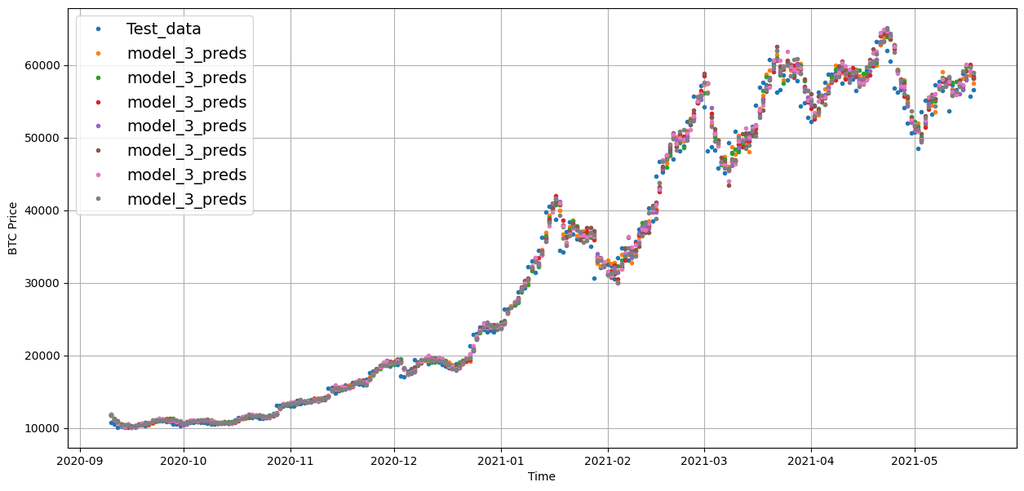

```python
offset = 300
plt.figure(figsize=(15,7))
plot_time_series(timesteps=X_test[-len(test_windows):], values=test_labels[:,0], start=offset, label='Test_data')
plot_time_series(timesteps=X_test[-len(test_windows):], values=model_3_preds, start=offset, label='model_3_preds')
```

We now get a funky lookin plot, due to the constant overlap of 7 different predictions at once - we can sort this out by using `mean` again like the function.

This does mean we lose the information of the model, predicting 7 days in advance, as now we're treating it like it's only predicting 1 day ahead.

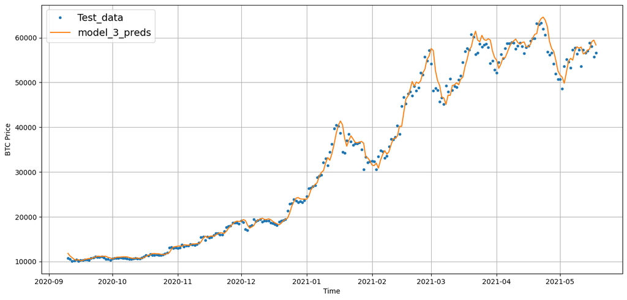

```python
offset = 300
plt.figure(figsize=(15,7))
# plot model_3_preds by aggregating them
plot_time_series(timesteps=X_test[-len(test_windows):],values=test_labels[:,0],start=offset,label='Test_data')
plot_time_series(timesteps=X_test[-len(test_windows):],values=tf.reduce_mean(model_3_preds,axis=1),format='-',start=offset,label='model_3_preds')
```

### Which of our models are performing best so far?

So far only 3 models have been experimented upon - let's compare its `mae` results with the Naive model as well.

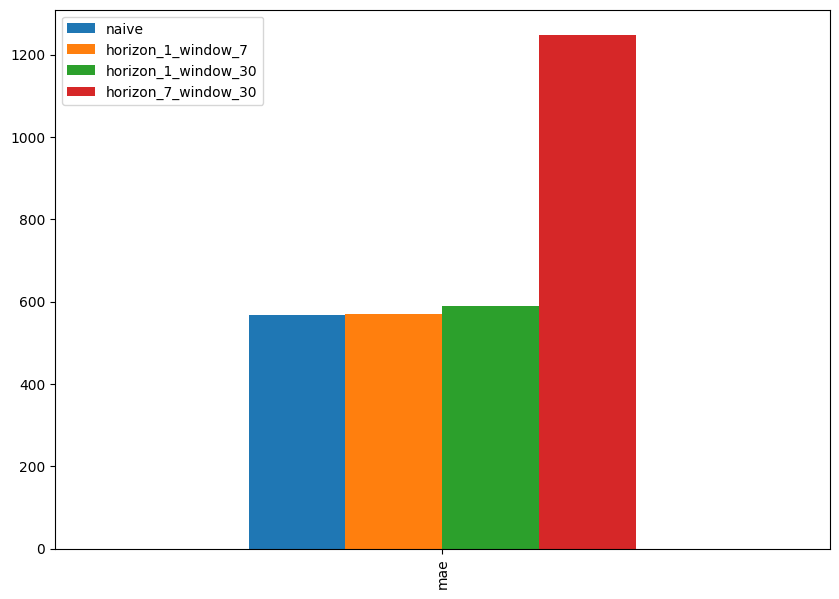

```python
pd.DataFrame({'naive': naive_results['mae'],
              'horizon_1_window_7': model_1_results['mae'],
              'horizon_1_window_30': model_2_results['mae'],
              'horizon_7_window_30': model_3_results['mae']}, index=['mae']).plot(figsize=(10,7),kind='bar');
```

With `HORIZON=1` and `WINDOW_SIZE=7` being the closest to naive model, we'll utilize it on our next series of models over the others due to performance.

### Model 4: Conv1D

We'll be using a Conv1D model, as it can be used for sequence to sequence problems. For our case, that's 7 days of past Bitcoin price to output tomorrow's price. (This is called `many to one` problem).

[figure not shown]

Before we build a Conv1D model,let's recreate our datasets.

```python
HORIZON=1
WINDOW_SIZE=7
```

```python
# create windowed dataset
full_windows, full_labels = make_windows(prices, window_size=WINDOW_SIZE, horizon=HORIZON)
len(full_windows), len(full_labels)
```

```
(2780, 2780)
```

```python
# Create train/test splits
train_windows, test_windows, train_labels, test_labels = make_train_test_splits(full_windows, full_labels)
len(train_windows), len(test_windows), len(train_labels), len(test_labels)
```

```
(2224, 556, 2224, 556)
```

Since we're using Conv1D, we need to make sure input shapes are correct.

The Conv1D layer takes the following input: (`batch_size`,`timesteps`,`input_dim`).

In our case, the `batch_size` (default is 32) is handled for us, but other values would be:

`timesteps = WINDOW_SIZE` and `input_dim = HORIZON`

Let's do the nessecary adjustments for our `input_dim`, as our `timesteps` has been completed already.

```python
# check data sample shapes
train_windows[0].shape # returns (WINDOW_SIZE,)
```

```
(7,)
```

To fix that, we can adjust `train_windows` shape or use `tf.keras.layers.Lambda`. The lambda layer wraps a function into a layer which can be used with a model.

Let's try it out.

```python
# before passing conv1d layer, reshape it to our data
x = tf.constant(train_windows[0]) # turn into a tensor from its original data type
expand_dims_layer = layers.Lambda(lambda x: tf.expand_dims(x, axis=1)) # adding extra dimension for timestep
print(f'Original shape: {x.shape}') # (WINDOW_SIZE)
print(f'Expanded shape: {expand_dims_layer(x).shape}') # (WINDOW_SIZE, input_dims)
print(f'Original values with expanded shape: \n {expand_dims_layer(x)}')
print(f'Old values of original shape: \n {(x)}')
```

```
Original shape: (7,)
Expanded shape: (7, 1)
Original values with expanded shape:
 [[123.65499]
 [125.455  ]
 [108.58483]
 [118.67466]
 [121.33866]
 [120.65533]
 [121.795  ]]
Old values of original shape:
 [123.65499 125.455   108.58483 118.67466 121.33866 120.65533 121.795  ]
```

Now let's begin compiling, fitting and evaluating the Conv1D model on our data.

```python
tf.random.set_seed(35)

# create model
model_4 =tf.keras.Sequential([
    # create Lambda layer to reshape inputs, without this layer the model will error
    layers.Lambda(lambda x: tf.expand_dims(x, axis=1)), # resize the inputs to adjust for window size / Conv1D 3D input requirements
    layers.Conv1D(filters=128, kernel_size=5, padding='causal', activation='relu'),
    # kernel_size=5 > looking at 5 timesteps at a time
    # padding='causal' > tells conv1d to not see future values (if we don't have this, data leakage will happen!)
    layers.Dense(HORIZON)
], name='model_4_conv1D')

# compile model
model_4.compile(loss='mae',
                optimizer=tf.keras.optimizers.Adam())

# fit model
model_4.fit(train_windows,train_labels,
            batch_size=128,epochs=100,
            verbose=0,
            validation_data=(test_windows,test_labels),
            callbacks=[create_model_checkpoint(model_name=model_4.name)])
```

[output not shown]

[output not shown]

[output not shown]

[output not shown]

[output not shown]

[output not shown]

[output not shown]

[output not shown]

[output not shown]

[output not shown]

[output not shown]

[output not shown]

[output not shown]

[output not shown]

[output not shown]

[output not shown]

[output not shown]

[output not shown]

[output not shown]

[output not shown]

[output not shown]

[output not shown]

[output not shown]

[output not shown]

[output not shown]

[output not shown]

[output not shown]

[output not shown]

[output not shown]

[output not shown]

[output not shown]

[output not shown]

[output not shown]

[output not shown]

[output not shown]

[output not shown]

[output not shown]

[output not shown]

[output not shown]

[output not shown]

[output not shown]

[output not shown]

[output not shown]

[output not shown]

[output not shown]

[output not shown]

[output not shown]

[output not shown]

[output not shown]

[output not shown]

[output not shown]

[output not shown]

[output not shown]

[output not shown]

[output not shown]

[output not shown]

[output not shown]

[output not shown]

[output not shown]

[output not shown]

[output not shown]

[output not shown]

[output not shown]

[output not shown]

[output not shown]

[output not shown]

[output not shown]

[output not shown]

[output not shown]

[output not shown]

[output not shown]

[output not shown]

```
<keras.src.callbacks.History at 0x232aa98f940>
```

Let's check the summary with the lambda layer

```python
model_4.summary()
```

```
Model: "model_4_conv1D"
_________________________________________________________________
 Layer (type)                Output Shape              Param #
=================================================================
 lambda_21 (Lambda)          (None, 1, 7)              0

 conv1d_5 (Conv1D)           (None, 1, 128)            4608

 dense_14 (Dense)            (None, 1, 1)              129

=================================================================
Total params: 4737 (18.50 KB)
Trainable params: 4737 (18.50 KB)
Non-trainable params: 0 (0.00 Byte)
_________________________________________________________________
```

Lambda layer appears like any regular layer - now let's evaluate on Conv1D model.

```python
# load in best performing conv1d model, and evaluate on test data
model_4 = tf.keras.models.load_model('model_experiments/model_4_conv1D')
model_4.evaluate(test_windows,test_labels)
```

```
569.6724243164062
```

```python
# make predictions
model_4_preds = make_preds(model_4, test_windows)
model_4_preds[:10]
```

```
<tf.Tensor: shape=(10,), dtype=float32, numpy=
array([8895.246, 8791.787, 8998.989, 8808.992, 8744.538, 8726.023,
       8689.595, 8546.053, 8457.912, 8517.925], dtype=float32)>
```

```python
# Evaluate predictions
model_4_results = evaluate_preds(y_true=tf.squeeze(test_labels),
                                 y_pred=model_4_preds)
model_4_results
```

```
{'mae': 569.6724,
 'mse': 1185561.4,
 'rmse': 1088.8348,
 'mape': 2.5550425,
 'mase': 1.0007566}
```

### Model 5: RNN (LSTM)

RNN can also be utilized with sequential time series data - we will continue using the same data from `model_4` of Conv1D.

We have to make sure our data is in the right shape. The `tf.keras.layers.LSTM()` layer takes tensors with `[batch, timesteps, feature]` dimensions.

`batch` is taken care of from the model, with have the `timesteps` feature aka our WINDOW_SIZE, but only one `feature` - and our data looks like `[1000,7]` (`[batch,timestep]`).

```python
tf.random.set_seed(35)

# let's build an LSTM model with the Functional API
inputs = layers.Input(shape=(WINDOW_SIZE))
x = layers.Lambda(lambda x: tf.expand_dims(x,axis=1))(inputs) # expand dims at the end, to be compatible due to `features` dimension being included
# print(x.shape) = (None, 1, 7)
x = layers.LSTM(128, activation='relu')(x)
# print(x.shape) = (None, 128)
output = layers.Dense(HORIZON)(x)
model_5 = tf.keras.Model(inputs=inputs, outputs=output, name='model_5_lstm')

# Compile model
model_5.compile(loss='mae',
                optimizer=tf.keras.optimizers.Adam())

model_5.fit(train_windows,train_labels,
            epochs=100,verbose=0,
            batch_size=128,
            validation_data=(test_windows,test_labels),
            callbacks=[create_model_checkpoint(model_name=model_5.name)])
```

[output not shown]

[output not shown]

[output not shown]

[output not shown]

[output not shown]

[output not shown]

[output not shown]

[output not shown]

[output not shown]

[output not shown]

[output not shown]

[output not shown]

[output not shown]

[output not shown]

[output not shown]

[output not shown]

[output not shown]

[output not shown]

[output not shown]

[output not shown]

[output not shown]

[output not shown]

[output not shown]

[output not shown]

[output not shown]

[output not shown]

[output not shown]

[output not shown]

[output not shown]

[output not shown]

[output not shown]

[output not shown]

[output not shown]

[output not shown]

[output not shown]

[output not shown]

[output not shown]

[output not shown]

[output not shown]

[output not shown]

[output not shown]

[output not shown]

[output not shown]

[output not shown]

[output not shown]

[output not shown]

[output not shown]

[output not shown]

[output not shown]

[output not shown]

[output not shown]

[output not shown]

[output not shown]

[output not shown]

[output not shown]

[output not shown]

[output not shown]

[output not shown]

[output not shown]

[output not shown]

[output not shown]

[output not shown]

[output not shown]

[output not shown]

[output not shown]

[output not shown]

[output not shown]

[output not shown]

[output not shown]

[output not shown]

[output not shown]

[output not shown]

[output not shown]

[output not shown]

[output not shown]

[output not shown]

[output not shown]

[output not shown]

[output not shown]

[output not shown]

[output not shown]

[output not shown]

[output not shown]

[output not shown]

[output not shown]

[output not shown]

[output not shown]

[output not shown]

[output not shown]

[output not shown]

[output not shown]

[output not shown]

[output not shown]

[output not shown]

[output not shown]

[output not shown]

[output not shown]

[output not shown]

[output not shown]

[output not shown]

[output not shown]

[output not shown]

[output not shown]

[output not shown]

[output not shown]

[output not shown]

[output not shown]

[output not shown]

[output not shown]

[output not shown]

[output not shown]

[output not shown]

```
<keras.src.callbacks.History at 0x232aaa86fb0>
```

```python
model_5.summary()
```

```
Model: "model_5_lstm"
_________________________________________________________________
 Layer (type)                Output Shape              Param #
=================================================================
 input_5 (InputLayer)        [(None, 7)]               0

 lambda_22 (Lambda)          (None, 1, 7)              0

 lstm_3 (LSTM)               (None, 128)               69632

 dense_15 (Dense)            (None, 1)                 129

=================================================================
Total params: 69761 (272.50 KB)
Trainable params: 69761 (272.50 KB)
Non-trainable params: 0 (0.00 Byte)
_________________________________________________________________
```

You can see from the printing text that has been `hashed` out, that it matches the output shapes.

```python
# load in the best model of model_5 and evaluate
model_5 = tf.keras.models.load_model('model_experiments/model_5_lstm/')
model_5.evaluate(test_windows,test_labels)
```

```
581.1947631835938
```

Now with best performing loaded in, let's make predictions

```python
# make predictions with out LSTM model
model_5_preds = make_preds(model_5, test_windows)
model_5_preds[:10]
```

```
<tf.Tensor: shape=(10,), dtype=float32, numpy=
array([8904.969, 8781.992, 8968.203, 8786.073, 8730.459, 8733.274,
       8661.902, 8543.612, 8449.206, 8501.356], dtype=float32)>
```

```python
# evaluate model 5 preds
model_5_results = evaluate_preds(y_true=tf.squeeze(test_labels),
                                 y_pred=model_5_preds)
model_5_results
```

```
{'mae': 581.19476,
 'mse': 1217983.8,
 'rmse': 1103.623,
 'mape': 2.6041665,
 'mase': 1.0209982}
```

This is the prediction evaluation from naive model

```
{'mae': 567.9802,
 'mse': 1147547.0,
 'rmse': 1071.2362,
 'mape': 2.5165248,
 'mase': 0.99957}
```

**NOTE:** I messed up the training of the model which created the wrong predictions because of our 'throwaway' function that fucked everything up from `model_4`. I've added the changes.

These were the prediction made before:

```
{'mae': 202.80865,
 'mse': 248348.2,
 'rmse': 498.34546,
 'mape': 3.1148615,
 'mase': 0.024086276}
```

Apparently its done extremely well which is surprising (the workbook im studying from shows a worse score than naive model). Let's still visualize model 5 and see whats going on.

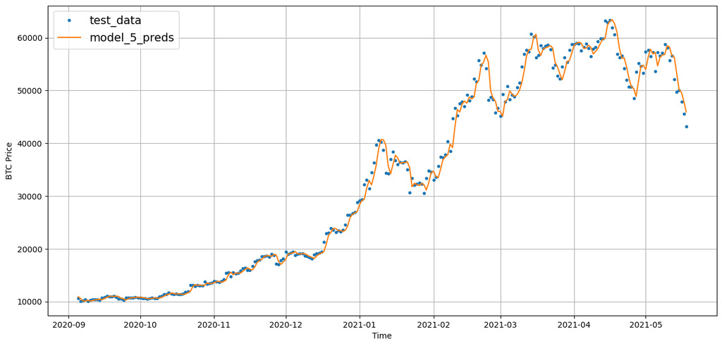

```python
# viz the model
offset = 300
plt.figure(figsize=(15,7))

plot_time_series(timesteps=X_test[-len(test_windows):], values=test_labels[:,0], start=offset, label='test_data')
plot_time_series(timesteps=X_test[-len(test_windows):], values=model_5_preds, start=offset, format='-', label='model_5_preds');
```

I used `train_test_split`, which was a demonstration of what NOT to do on time series data, instead of `make_train_test_split`, causing the confusion and errors. This is what it'll do to the data:

[figure not shown]

### Make multivariate time series

If predicting bitcoin price solely based on previous dates of the price, maybe we can try give the model more information/features to do the predicting.

*More information* is vague in the case, where we could essentially feed anything and the model will try and find patterns regardless. However what's better is passing information with relations to bitcoin.

What we could try is use `bitcoin block reward size`. But what's that? Its the reward that one gets for mining a bitcoin, and that size varies. During inception, it was 50 bitcoins, but every four years they half the reward.

Let's encode the info into our time series data, and see if it helps with performance.

> **Note**: Our data now goes from `univariate` to `multivariate`.

```python
# Let's make a multivariate time series
bitcoin_prices.head()
```

| Date | Price |
| --- | --- |
| 2013-10-01 | 123.65499 |
| 2013-10-02 | 125.45500 |
| 2013-10-03 | 108.58483 |
| 2013-10-04 | 118.67466 |
| 2013-10-05 | 121.33866 |

Time to add another feature column for block reward size.

We'll create variable for the different block reward size as well we the dates they came into play.

The following block rewards and dates were sourced from cmcmarkets.com.

[output not shown]

```python
# Block reward values
block_reward_1 = 50 # 3 January 2009 (2009-01-03) - this block reward isn't in our dataset (it starts from 01 October 2013)
block_reward_2 = 25 # 28 November 2012
block_reward_3 = 12.5 # 9 July 2016
block_reward_4 = 6.25 # 11 May 2020

# Block reward dates (datetime form of the above date stamps)
block_reward_2_datetime = np.datetime64("2012-11-28")
block_reward_3_datetime = np.datetime64("2016-07-09")
block_reward_4_datetime = np.datetime64("2020-05-11")
```

We also have to make sure the value stretches through the entire data, and fully indexed, otherwise it'll affect the original variable for not aligning together. All features need to be in the same frequency, or otherwise using data cleaning techniques to fill gaps is that is needed.

```python
# get date indexes for when to add in different block dates
block_reward_2_days = (block_reward_3_datetime - bitcoin_prices.index[0]).days
block_reward_3_days = (block_reward_4_datetime - bitcoin_prices.index[0]).days
block_reward_2_days, block_reward_3_days
```

```
(1012, 2414)
```

Now we can add another feature to our dataset `block_reward`

```python
# add block_reward column
bitcoin_prices_block = bitcoin_prices.copy() # creating new multivariate data frame
bitcoin_prices_block['block_reward'] = None

# set value of block_reward column (use -1 indexing for iloc to apply from latest index all the way to first index)
bitcoin_prices_block.iloc[:block_reward_2_days,-1] = block_reward_2
bitcoin_prices_block.iloc[block_reward_2_days:block_reward_3_days,-1] = block_reward_3
bitcoin_prices_block.iloc[block_reward_3_days:,-1] = block_reward_4
bitcoin_prices_block.head()
```

| Date | Price | block_reward |
| --- | --- | --- |
| 2013-10-01 | 123.65499 | 25 |
| 2013-10-02 | 125.45500 | 25 |
| 2013-10-03 | 108.58483 | 25 |
| 2013-10-04 | 118.67466 | 25 |
| 2013-10-05 | 121.33866 | 25 |

Let's now visualize it in graph form

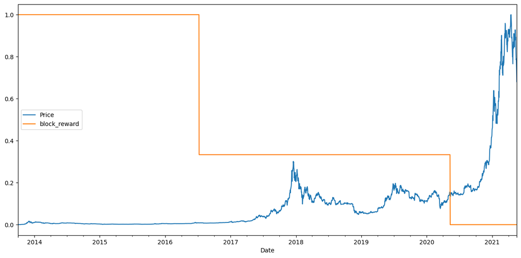

```python
from sklearn.preprocessing import minmax_scale

scaled_price_block_df = pd.DataFrame(minmax_scale(bitcoin_prices_block[['Price','block_reward']]), # scale features, so they fit together, and not heavily different
                                    columns=bitcoin_prices_block.columns,
                                    index=bitcoin_prices_block.index)

scaled_price_block_df.plot(figsize=(15,7));
```

Theres a visible correlation to smaller `block_reward` = larger `price`.

### Making a windowed dataset with pandas

We made a custom function to window our `univariate` time series. But with the new added variable, the function won't work.

Fortunately we have the `pandas.DataFrame.shift()` method to create a windowed **multivariate** time series.

The `shift()` method offsets an index by a specified number of periods.

```python
# set data hyperparam
HORIZON=1
WINDOW_SIZE=7
```

```python
# make a copy of the bitcoin historical data with block reward feature
bitcoin_prices_windowed = bitcoin_prices_block.copy()

# add windowed columns
for i in range(WINDOW_SIZE): # shift values for each step by `WINDOW_SIZE`
    bitcoin_prices_windowed[f'Price+{i+1}'] = bitcoin_prices_windowed['Price'].shift(periods=i+1)

bitcoin_prices_windowed.head(10)
```

| Date | Price | block_reward | Price+1 | Price+2 | Price+3 | Price+4 | Price+5 | Price+6 | Price+7 |
| --- | --- | --- | --- | --- | --- | --- | --- | --- | --- |
| 2013-10-01 | 123.65499 | 25 | NaN | NaN | NaN | NaN | NaN | NaN | NaN |
| 2013-10-02 | 125.45500 | 25 | 123.65499 | NaN | NaN | NaN | NaN | NaN | NaN |
| 2013-10-03 | 108.58483 | 25 | 125.45500 | 123.65499 | NaN | NaN | NaN | NaN | NaN |
| 2013-10-04 | 118.67466 | 25 | 108.58483 | 125.45500 | 123.65499 | NaN | NaN | NaN | NaN |
| 2013-10-05 | 121.33866 | 25 | 118.67466 | 108.58483 | 125.45500 | 123.65499 | NaN | NaN | NaN |
| 2013-10-06 | 120.65533 | 25 | 121.33866 | 118.67466 | 108.58483 | 125.45500 | 123.65499 | NaN | NaN |
| 2013-10-07 | 121.79500 | 25 | 120.65533 | 121.33866 | 118.67466 | 108.58483 | 125.45500 | 123.65499 | NaN |
| 2013-10-08 | 123.03300 | 25 | 121.79500 | 120.65533 | 121.33866 | 118.67466 | 108.58483 | 125.45500 | 123.65499 |
| 2013-10-09 | 124.04900 | 25 | 123.03300 | 121.79500 | 120.65533 | 121.33866 | 118.67466 | 108.58483 | 125.45500 |
| 2013-10-10 | 125.96116 | 25 | 124.04900 | 123.03300 | 121.79500 | 120.65533 | 121.33866 | 118.67466 | 108.58483 |

Let's now separate the `X` features from our `y` label. We're wanting to use `WINDOW_SIZE` to predict `HORIZON` steps.

```
Window for a week (7) to predict a horizon of 1 (multivariate time series)
WINDOW_SIZE & block_reward -> HORIZON

[0, 1, 2, 3, 4, 5, 6, block_reward] -> [7]
[1, 2, 3, 4, 5, 6, 7, block_reward] -> [8]
[2, 3, 4, 5, 6, 7, 8, block_reward] -> [9]
```

We'll also remove nan via `dropna()` method. Which is equivalent to starting our window function at `sample 0 (first cample) + WINDOW_SIZE`.

```python
# create x and y data, and remove NANs + convert to float32 to prevent tf errors
X = bitcoin_prices_windowed.dropna().drop("Price",axis=1).astype(np.float32)
y = bitcoin_prices_windowed.dropna()['Price'].astype(np.float32)
X.head()
```

| Date | block_reward | Price+1 | Price+2 | Price+3 | Price+4 | Price+5 | Price+6 | Price+7 |
| --- | --- | --- | --- | --- | --- | --- | --- | --- |
| 2013-10-08 | 25.0 | 121.794998 | 120.655327 | 121.338661 | 118.674660 | 108.584831 | 125.455002 | 123.654991 |
| 2013-10-09 | 25.0 | 123.032997 | 121.794998 | 120.655327 | 121.338661 | 118.674660 | 108.584831 | 125.455002 |
| 2013-10-10 | 25.0 | 124.049004 | 123.032997 | 121.794998 | 120.655327 | 121.338661 | 118.674660 | 108.584831 |
| 2013-10-11 | 25.0 | 125.961159 | 124.049004 | 123.032997 | 121.794998 | 120.655327 | 121.338661 | 118.674660 |
| 2013-10-12 | 25.0 | 125.279663 | 125.961159 | 124.049004 | 123.032997 | 121.794998 | 120.655327 | 121.338661 |

```python
# view label
y.head()
```

```
Date
2013-10-08    123.032997
2013-10-09    124.049004
2013-10-10    125.961159
2013-10-11    125.279663
2013-10-12    125.927498
Name: Price, dtype: float32
```

Let's split train/test 80/20

```python
# make train and test sets
split_size = int(len(X) * 0.8)
X_train, y_train = X[:split_size], y[:split_size]
X_test, y_test = X[split_size:], y[split_size:]
len(X_train),len(y_train),len(X_test),len(y_test)
```

```
(2224, 2224, 556, 556)
```

### Model 6: Dense (multivariate time series) + Block reward

To keep things simple, we'll use `model_1` architecture and use it to train and make predictions on our multivariate time series data.

By replicating the `model_1` architecture, we'll be able to see whether or not adding the block reward affects prediction capabilities.

```python
tf.random.set_seed(35)

# multivariate time series model
model_6 = tf.keras.Sequential([
    layers.Dense(128, activation='relu'),
    # layers.Dense(128, activation='relu'), # adding an extra layer here could lead to beating naive model
    layers.Dense(HORIZON)],
    name='model_6_dense_multivariate')

# compile
model_6.compile(loss='mae',
                optimizer=tf.keras.optimizers.Adam())

# fit
model_6.fit(X_train,y_train,
            epochs=100,
            batch_size=128,
            verbose=0,
            validation_data=(X_test,y_test),
            callbacks=[create_model_checkpoint(model_name=model_6.name)])
```

[output not shown]

[output not shown]

[output not shown]

[output not shown]

[output not shown]

[output not shown]

[output not shown]

[output not shown]

[output not shown]

[output not shown]

[output not shown]

[output not shown]

[output not shown]

[output not shown]

[output not shown]

[output not shown]

[output not shown]

[output not shown]

[output not shown]

[output not shown]

[output not shown]

[output not shown]

[output not shown]

[output not shown]

[output not shown]

[output not shown]

[output not shown]

[output not shown]

[output not shown]

[output not shown]

[output not shown]

[output not shown]

[output not shown]

[output not shown]

[output not shown]

[output not shown]

[output not shown]

[output not shown]

[output not shown]

[output not shown]

[output not shown]

[output not shown]

[output not shown]

[output not shown]

[output not shown]

[output not shown]

[output not shown]

[output not shown]

[output not shown]

[output not shown]

[output not shown]

[output not shown]

[output not shown]

[output not shown]

[output not shown]

[output not shown]

[output not shown]

[output not shown]

[output not shown]

[output not shown]

[output not shown]

[output not shown]

[output not shown]

[output not shown]

[output not shown]

[output not shown]

```
<keras.src.callbacks.History at 0x1d020877400>
```

Time to evaluate the model

```python
# make sure best model is loaded and evaluate
model_6 = tf.keras.models.load_model('model_experiments/model_6_dense_multivariate')
model_6.evaluate(X_test,y_test)
```

```
569.9911499023438
```

```python
# make predictions on muiltivariate data
model_6_preds = tf.squeeze(model_6.predict(X_test))
model_6_preds[:10]
```

```
<tf.Tensor: shape=(10,), dtype=float32, numpy=
array([8862.406, 8756.734, 9007.352, 8793.156, 8721.877, 8712.342,
       8707.98 , 8490.133, 8459.035, 8514.805], dtype=float32)>
```

```python
# evaluate preds
model_6_results = evaluate_preds(y_true=y_test,
                                 y_pred=model_6_preds)
model_6_results
```

```
{'mae': 569.99115,
 'mse': 1171590.2,
 'rmse': 1082.4003,
 'mape': 2.5561154,
 'mase': 1.0013165}
```

Let's see how it compares to `model_1`.

```python
model_1_results
```

```
{'mae': 564.84296,
 'mse': 1150266.8,
 'rmse': 1072.5049,
 'mape': 2.5312698,
 'mase': 0.9922726}
```

Seems like the extra block of data made an inverse improvement, though marginally.

There are a few extracurriculars for the model we can try in the mean time:

1. Adding `tf.keras.layers.Dense()` layer with 128 hidden units to `moel_6`.
2. Is there a better way to create the model with `block_reward` data? Should it be bundled with bitcoin historical price feature? Maybe could try multi-input model, e.g. one model input for Bitcoin price history and one model input for `block_reward`.

#### Model_6_1 - use Dense(128)

The line was commented out - let's remove it and see performance in comparison to `model_6` itself.

```python
tf.random.set_seed(35)

# multivariate time series model
model_6_1 = tf.keras.Sequential([
    layers.Dense(128, activation='relu'),
    layers.Dense(128, activation='relu'),
    layers.Dense(HORIZON)],
    name='model_6_1_dense_multivariate')

# compile
model_6_1.compile(loss='mae',
                optimizer=tf.keras.optimizers.Adam())

# fit
model_6_1.fit(X_train,y_train,
            epochs=100,
            batch_size=128,
            verbose=0,
            validation_data=(X_test,y_test),
            callbacks=[create_model_checkpoint(model_name=model_6_1.name)])
```

[output not shown]

[output not shown]

[output not shown]

[output not shown]

[output not shown]

[output not shown]

[output not shown]

[output not shown]

[output not shown]

[output not shown]

[output not shown]

[output not shown]

[output not shown]

[output not shown]

[output not shown]

[output not shown]

[output not shown]

[output not shown]

[output not shown]

[output not shown]

[output not shown]

[output not shown]

[output not shown]

[output not shown]

[output not shown]

[output not shown]

[output not shown]

[output not shown]

[output not shown]

[output not shown]

[output not shown]

[output not shown]

[output not shown]

[output not shown]

[output not shown]

[output not shown]

[output not shown]

[output not shown]

[output not shown]

[output not shown]

```
<keras.src.callbacks.History at 0x1d027670370>
```

```python
# make sure best model is loaded and evaluate
model_6_1 = tf.keras.models.load_model('model_experiments/model_6_1_dense_multivariate')
model_6_1.evaluate(X_test,y_test)
```

```
565.9505615234375
```

```python
# make predictions on muiltivariate data
model_6_1_preds = tf.squeeze(model_6_1.predict(X_test))
model_6_1_preds[:10]
```

```
<tf.Tensor: shape=(10,), dtype=float32, numpy=
array([8825.603, 8775.072, 9050.104, 8753.727, 8732.031, 8746.877,
       8666.061, 8519.976, 8451.378, 8532.227], dtype=float32)>
```

```python
# evaluate preds
model_6_1_results = evaluate_preds(y_true=y_test,
                                 y_pred=model_6_1_preds)
model_6_1_results
```

```
{'mae': 565.95056,
 'mse': 1157438.2,
 'rmse': 1075.843,
 'mape': 2.5502508,
 'mase': 0.9942184}
```

```python
model_6_results
```

```
{'mae': 569.99115,
 'mse': 1171590.2,
 'rmse': 1082.4003,
 'mape': 2.5561154,
 'mase': 1.0013165}
```

There is some slight improvement, let's move onto:

#### Model_6_2 - Use multi input model

We will enlist the help of chatgpt to extrapolate our data, with a multivariate model that was mode on `09 notebook`.

```python
X_train
```

| Date | block_reward | Price+1 | Price+2 | Price+3 | Price+4 | Price+5 | Price+6 | Price+7 |
| --- | --- | --- | --- | --- | --- | --- | --- | --- |
| 2013-10-08 | 25.0 | 121.794998 | 120.655327 | 121.338661 | 118.674660 | 108.584831 | 125.455002 | 123.654991 |
| 2013-10-09 | 25.0 | 123.032997 | 121.794998 | 120.655327 | 121.338661 | 118.674660 | 108.584831 | 125.455002 |
| 2013-10-10 | 25.0 | 124.049004 | 123.032997 | 121.794998 | 120.655327 | 121.338661 | 118.674660 | 108.584831 |
| 2013-10-11 | 25.0 | 125.961159 | 124.049004 | 123.032997 | 121.794998 | 120.655327 | 121.338661 | 118.674660 |
| 2013-10-12 | 25.0 | 125.279663 | 125.961159 | 124.049004 | 123.032997 | 121.794998 | 120.655327 | 121.338661 |
| ... | ... | ... | ... | ... | ... | ... | ... | ... |
| 2019-11-05 | 12.5 | 9202.415039 | 9290.896484 | 9197.632812 | 9131.410156 | 9225.995117 | 9455.724609 | 9458.223633 |
| 2019-11-06 | 12.5 | 9369.627930 | 9202.415039 | 9290.896484 | 9197.632812 | 9131.410156 | 9225.995117 | 9455.724609 |
| 2019-11-07 | 12.5 | 9326.599609 | 9369.627930 | 9202.415039 | 9290.896484 | 9197.632812 | 9131.410156 | 9225.995117 |
| 2019-11-08 | 12.5 | 9335.751953 | 9326.599609 | 9369.627930 | 9202.415039 | 9290.896484 | 9197.632812 | 9131.410156 |
| 2019-11-09 | 12.5 | 9226.485352 | 9335.751953 | 9326.599609 | 9369.627930 | 9202.415039 | 9290.896484 | 9197.632812 |

2224 rows × 8 columns

```python
y_train
```

```
Date
2013-10-08     123.032997
2013-10-09     124.049004
2013-10-10     125.961159
2013-10-11     125.279663
2013-10-12     125.927498
                 ...
2019-11-05    9369.627930
2019-11-06    9326.599609
2019-11-07    9335.751953
2019-11-08    9226.485352
2019-11-09    8794.358398
Name: Price, Length: 2224, dtype: float32
```

```python
# Price features (window)
X_train_price = X_train.drop(columns=["block_reward"]).values.astype(np.float32)
X_test_price  = X_test.drop(columns=["block_reward"]).values.astype(np.float32)

# Block reward (separate input)
X_train_block = X_train["block_reward"].values.astype(np.float32)
X_test_block  = X_test["block_reward"].values.astype(np.float32)

# reshape block data from (2224,) to (2224,1) > keras expects 2d data, as the 2nd dim is where the number of features of the data is stored.
# We only have one feature `block reward`, and is therefore left as 1.
X_train_block = X_train_block.reshape(-1, 1)
X_test_block  = X_test_block.reshape(-1, 1)
# -1 is used to let pc auto find the number of rows in said data, aka by finding it's last index pos. 2224
```

```python
tf.random.set_seed(35)

# ----- Price input branch -----
price_input = layers.Input(shape=(X_train_price.shape[1],), name="price_input") # lets model know the per sample input is 7 features, aka the WINDOW_SIZE

x_price = layers.Dense(128, activation='relu')(price_input)
x_price = layers.Dense(64, activation='relu')(x_price)

price_model = tf.keras.Model(inputs=price_input, outputs=x_price) # tells model how data starts and ends, via input and output data
# very important when models are combining outputs together, in which this helps models understand process of branches and where it lies


# ----- Block reward branch -----
block_input = layers.Input(shape=(1,), name="block_input")

x_block = layers.Dense(16, activation='relu')(block_input)
x_block = layers.Dense(8, activation='relu')(x_block)

block_model = tf.keras.Model(inputs=block_input, outputs=x_block)


# ----- Combine -----
combined = layers.Concatenate()([price_model.output, block_model.output])

x = layers.Dense(128, activation='relu')(combined)
x = layers.Dense(64, activation='relu')(x)

output = layers.Dense(1)(x)  # regression


# ----- Final model -----
model_multi = tf.keras.Model(
    inputs=[price_model.input, block_model.input],
    outputs=output
)
# similar to the model establishing on price and block_reward, needing input and output info

# compile
model_multi.compile(
    loss='mae',
    optimizer=tf.keras.optimizers.Adam()
)
```

```python
model_multi.fit(
    [X_train_price, X_train_block],
    y_train,
    epochs=100,
    batch_size=128,
    validation_data=([X_test_price, X_test_block], y_test),
    callbacks=[create_model_checkpoint(model_name="model_multi")]
)
```

[output not shown]

[output not shown]

[output not shown]

[output not shown]

[output not shown]

[output not shown]

[output not shown]

[output not shown]

[output not shown]

[output not shown]

[output not shown]

[output not shown]

[output not shown]

[output not shown]

[output not shown]

[output not shown]

[output not shown]

[output not shown]

[output not shown]

[output not shown]

```
<keras.src.callbacks.History at 0x1d0227b62c0>
```

```python
# make sure best model is loaded and evaluate
model_6_2 = tf.keras.models.load_model('model_experiments/model_multi')

X_test_price = X_test.drop(columns=["block_reward"]).values.astype(np.float32)
X_test_block = X_test["block_reward"].values.astype(np.float32).reshape(-1, 1)

model_6_2.evaluate(
    [X_test_price, X_test_block],
    y_test
)
```

```
564.9115600585938
```

```python
# make predictions on muiltivariate data
model_6_2_preds = tf.squeeze(
    model_6_2.predict([X_test_price, X_test_block]))
model_6_2_preds[:10]
```

```
<tf.Tensor: shape=(10,), dtype=float32, numpy=
array([8828.386, 8771.8  , 9036.003, 8745.616, 8747.042, 8748.02 ,
       8658.312, 8522.38 , 8453.589, 8526.581], dtype=float32)>
```

```python
model_6_2_results = evaluate_preds(y_true=y_test,
                                 y_pred=model_6_2_preds)
model_6_2_results
```

```
{'mae': 564.91174,
 'mse': 1153192.1,
 'rmse': 1073.8678,
 'mape': 2.5414999,
 'mase': 0.9923935}
```

```python
model_6_1_results
```

```
{'mae': 565.95056,
 'mse': 1157438.2,
 'rmse': 1075.843,
 'mape': 2.5502508,
 'mase': 0.9942184}
```

Seems that it has done marginally better, but clearly too much effort for that little difference.

### Model 7: N-BEATS algorithm

We've only ever tried models with a couple of layers, however model's performance is often correlated to number of layers. The more the merrier.

That's exactly what N-BEATS (Neural Basis Expansion Analysis for Interpretable Time Series Forecasting) algorithm does.

N-BEATS uses univariate time series problems, and achieved state-of-the-art performance on forecasting in `M4 competition`.

We will replicate the **generic architecture** of N-BEATS algorithm. As we will focus on:

1. Replicating the model architecture:

[figure not shown]

*N-BEATS algorithm as above will be replicated with TensorFlow with window(input) and horizon (output) annotations.*

2. Using the same hyperparameters as the paper.

It will allow use to practice:

- Creating custom layer for the `NBeatsBlock` by subclassing `tf.keras.layers.layer`.
  - Creating a custom layer is helpful for when tf doesn't have existing implementation of a layer (e.g. like a stock of N-BEATS blcoks)
- Implementing a custom architecture using the Functional API
- Finding a paper related to our problem and seeing how it goes

#### Building and testing an N-BEATS block layer

Let's start building N-BEATS block layer. We'll write code first then discuss what's it doing.

```python
# Create NBeatsBlock custom layer
class NBeatsBlock(tf.keras.layers.Layer):
  def __init__(self, # the constructor takes all the hyperparameters for the layer
               input_size: int,
               theta_size: int,
               horizon: int,
               n_neurons: int,
               n_layers: int,
               **kwargs): # the **kwargs argument takes care of all of the arguments for the parent class (input_shape, trainable, name)
    super().__init__(**kwargs)
    self.input_size = input_size
    self.theta_size = theta_size
    self.horizon = horizon
    self.n_neurons = n_neurons
    self.n_layers = n_layers

    # Block contains stack of 4 fully connected layers each has ReLU activation
    self.hidden = [tf.keras.layers.Dense(n_neurons, activation="relu") for _ in range(n_layers)]
    # Output of block is a theta layer with linear activation
    self.theta_layer = tf.keras.layers.Dense(theta_size, activation="linear", name="theta")

  def call(self, inputs): # the call method is what runs when the layer is called
    x = inputs
    for layer in self.hidden: # pass inputs through each hidden layer
      x = layer(x)
    theta = self.theta_layer(x)
    # Output the backcast and forecast from theta
    backcast, forecast = theta[:, :self.input_size], theta[:, -self.horizon:]
    return backcast, forecast
```

The `NBeatsBlock` custom layer performs the following:

- The class inherits from `tf.keras.layers.Layer` (give all methods associated to it)
- The constructor (`def __init__(...)`) takes all hyperparams and `**kwargs` argument
  - The `**kwargs` argument takes care of all hyperparams which aren't mentioned in the constructor. E.g. `input_shape`, `trainable` and name.
- In the constructor, the block architecture layers are created:
  - The hidden layers are created as a stack, fully connnected with `n_neurons` hidden units layers with ReLU activation
  - The theta uses `theta_size` hidden units as well as linear activation
- The `call()` method is what is run when the layer is called:

[output not shown]

> What does theta do?

We see it being combined with `WINDOW_SIZE` and `HORIZON`. It is a compressed summary of everything the block has learned. Rather than a separated learning of `past` and `future`, having them together in `theta`, allows the model to get a shared representation of both parties together. In a way, its like bringing the input and output variables into the model, so it understands how X becomes Y. Same thing with how `past` becomes `future.

```python
# Set up dummy NBeatsBlock layer to represent inputs and outputs
dummy_nbeats_block_layer = NBeatsBlock(input_size=WINDOW_SIZE,
                                       theta_size=WINDOW_SIZE+HORIZON, # backcast + forecast
                                       horizon=HORIZON,
                                       n_neurons=128,
                                       n_layers=4)
```

```python
# create dummy inputs (have to be same size as input_size)
dummy_inputs = tf.expand_dims(tf.range(WINDOW_SIZE) + 1, axis=0)
dummy_inputs
```

```
<tf.Tensor: shape=(1, 7), dtype=int32, numpy=array([[1, 2, 3, 4, 5, 6, 7]])>
```

```python
# pass dummy inputs to dummy NBeatsBlock layer
backcast, forecast = dummy_nbeats_block_layer(dummy_inputs)
# these are the activation outputs of the theta layer (they'll be random due to no training of the model)
print(f'Backcast: {tf.squeeze(backcast.numpy())}')
print(f'Forecast: {tf.squeeze(forecast.numpy())}')
```

```
Backcast: [-0.2356258  -0.10455819 -0.02919242 -0.13559982  0.36156276 -0.46000886
  0.14899412]
Forecast: -0.42499449849128723
```

### Preparing data for the N-BEATS algorithm using `tf.data`

Let's create proper data for the N-BEATS architecture. Due to largeness of model, we want to ensure training is fast, so will setup our datasets useing the `tf.data` API.

Since N-BEATS algorithm is focused on univariate time series, we'll start by making training and test windowed datasets of Bitcoin prices (as done above).

```python
HORIZON=1
WINDOW_SIZE=7

bitcoin_prices.head()
```

| Date | Price |
| --- | --- |
| 2013-10-01 | 123.65499 |
| 2013-10-02 | 125.45500 |
| 2013-10-03 | 108.58483 |
| 2013-10-04 | 118.67466 |
| 2013-10-05 | 121.33866 |

```python
# add windowed columns
bitcoin_prices_nbeats = bitcoin_prices.copy()
for i in range(WINDOW_SIZE):
    bitcoin_prices_nbeats[f'Price+{i+1}'] = bitcoin_prices_nbeats['Price'].shift(periods=i+1)
bitcoin_prices_nbeats.dropna().head()
```

| Date | Price | Price+1 | Price+2 | Price+3 | Price+4 | Price+5 | Price+6 | Price+7 |
| --- | --- | --- | --- | --- | --- | --- | --- | --- |
| 2013-10-08 | 123.03300 | 121.79500 | 120.65533 | 121.33866 | 118.67466 | 108.58483 | 125.45500 | 123.65499 |
| 2013-10-09 | 124.04900 | 123.03300 | 121.79500 | 120.65533 | 121.33866 | 118.67466 | 108.58483 | 125.45500 |
| 2013-10-10 | 125.96116 | 124.04900 | 123.03300 | 121.79500 | 120.65533 | 121.33866 | 118.67466 | 108.58483 |
| 2013-10-11 | 125.27966 | 125.96116 | 124.04900 | 123.03300 | 121.79500 | 120.65533 | 121.33866 | 118.67466 |
| 2013-10-12 | 125.92750 | 125.27966 | 125.96116 | 124.04900 | 123.03300 | 121.79500 | 120.65533 | 121.33866 |

```python
# make features and labels
X = bitcoin_prices_nbeats.dropna().drop('Price', axis=1)
y = bitcoin_prices_nbeats.dropna()['Price']

# make train test data
split_size = int(len(X) * 0.8)
X_train,y_train = X[:split_size],y[:split_size]
X_test,y_test = X[split_size:],y[split_size:]
len(X_train), len(y_train), len(X_test), len(y_test)
```

```
(2224, 2224, 556, 556)
```

Time to convert data to Tensorflow via `tf.data.Dataset`. We'll do this via:

1. Turning the arrays in tensor Datasets using `tf.data.Dataset.from_tensor_slices()`.
- Note: `from_tensor_slices()` works best when your data fits in memory, from extremely large datasets, you'll want to look into using the `TFRecord` format
2. Combine the labels and features tensors into a Dataset using `tf.data.Dataset.zip()`
3. Batch and prefetch the Datasets using `batch()` and `prefetch()`
- Batching and prefetching ensures the loading time from CPU (preparing data) to GPU (computing on data) is as small as possible.

```python
# 1. turn train test arrays into tf
train_features_dataset = tf.data.Dataset.from_tensor_slices(X_train)
train_labels_dataset = tf.data.Dataset.from_tensor_slices(y_train)

test_features_dataset = tf.data.Dataset.from_tensor_slices(X_test)
test_labels_dataset = tf.data.Dataset.from_tensor_slices(y_test)

# 2. Combine features and labels
train_dataset = tf.data.Dataset.zip((train_features_dataset,train_labels_dataset))
test_dataset = tf.data.Dataset.zip((test_features_dataset,test_labels_dataset))

# 3. Batch and prefetch for optimal performance
BATCH_SIZE = 1024 # token from appendix D in N-BEATS papers
train_dataset = train_dataset.batch(BATCH_SIZE).prefetch(tf.data.AUTOTUNE)
test_dataset = test_dataset.batch(BATCH_SIZE).prefetch(tf.data.AUTOTUNE)

train_dataset,test_dataset
```

```
(<_PrefetchDataset element_spec=(TensorSpec(shape=(None, 7), dtype=tf.float64, name=None), TensorSpec(shape=(None,), dtype=tf.float64, name=None))>,
 <_PrefetchDataset element_spec=(TensorSpec(shape=(None, 7), dtype=tf.float64, name=None), TensorSpec(shape=(None,), dtype=tf.float64, name=None))>)
```

Data prepeared :) See our data shape of `(None, 7)`, as the `None` leaves space for batch size, whilst 7 represents `WINDOW_SIZE`.

### Setting up hyperparameters fo N-BEATS algorithm

We'll create variables for each of the hyperparameters we'll be using for our N-BEATS replica.

[figure not shown]

> **Note**: If you see variables in all caps e.g. `N_EPOCHS = 100`, they are hyperparams which are used through the example, and would often be seen instantiated towards the start of experiment, and used throughout.

```python
# valute from N-BEATS paper
N_EPOCHS=5000 # called iterations in Table 18
N_NEURONS=512 # called width in Table 18
N_LAYERS=4
N_STACKS=30

INPUT_SIZE=WINDOW_SIZE*HORIZON # called lookback in Table 18
THETA_SIZE=INPUT_SIZE+HORIZON

INPUT_SIZE,THETA_SIZE
```

```
(7, 8)
```

### Getting ready for residual connections

Before creating N-BEATS model, there are two layers to go through which plays a large roll in the architecture.

Aka **Double residual stacking**:

- `tf.keras.layers.subtract(inputs)` - subtracts list of input tensors from each other
- `tf.keras.layers.add(input)` - adds list of input tensors to each other

```python
# make tensors
tensor_1 = tf.range(10)+10
tensor_2 = tf.range(10)

# subtract
subtracted = layers.subtract([tensor_1,tensor_2])

# add
added = layers.add([tensor_1,tensor_2])

print(f'Input tensors: {tensor_1.numpy()} & {tensor_2.numpy()}')
print(f'Subtracted: {subtracted.numpy()}')
print(f'Added: {added.numpy()}')
```

```
Input tensors: [10 11 12 13 14 15 16 17 18 19] & [0 1 2 3 4 5 6 7 8 9]
Subtracted: [10 10 10 10 10 10 10 10 10 10]
Added: [10 12 14 16 18 20 22 24 26 28]
```

Both are very straightforward - adding and subtracting from the other.

The power of **residual tracking/connections**, where the authors of the paper were able to build a deeper but less complex neural network.

A **residual connection** involves a deeper neural network layer recieving the outputs as well as the inputs of the shallower neural network layer. For n-beats, it uses residual connections which:

- Subtract the backcast outputs from a previous block from the backcast inputs to the current block
- Add the forecast outputs from all blocks together in a stack

[figure not shown]

Residual tracking is beneficial for deeper models (as n-beats reaches ~150 layers) as it's thought to help avoid issues like vanishing gradients.

### Building compiling and fitting N-BEATS algo

We'll do the following:

1. Setup an instance of the n-beats block layer using `NBeatsBlock` (used as initial block for network, rest will be created as part of stacks)
2. Create an input layer for the n-beats stack (we'll be using the `Keras Functional API`)
3. Make the initial backcast and forecasts for the model with the layer created in (1)
4. Use for loop to create stacks of block layers
5. Use the NBeatsBlock class within the for loop created in (4) to create blocks which return backcasts and block-level forecasts
6. Create the double residual stacking using subtract and add layers
7. Put the model inputs and outputs together using `tf.keras.Model()`
8. Compile the model with MAE loss and Adam optimizer with default settings
9. Fit the n-beats model for 5000 epochs and since it's fitting for so many epochs, we'll use callbacks:
   - `tf.keras.callbacks.EarlyStopping()` - stop model training if it doesn't improve val loss for 200 epochs, and restore best performing weights using `restore_best_weights=True`
   - `tf.keras.callbacks.ReduceLRonPlateau()` - if the model's validation loss doesn't improve for 100 epochs, reduce learning rate by x10 to make smaller incremental improvements

```python
%%time
tf.random.set_seed(35)

# 1. setup N-BEATS block layer
nbeats_block_layer = NBeatsBlock(input_size=INPUT_SIZE,
                                 theta_size=THETA_SIZE,
                                 horizon=HORIZON,
                                 n_neurons=N_NEURONS,
                                 n_layers=N_LAYERS,
                                 name='InitialBlock')

# 2. create input to stacks
stack_input = layers.Input(shape=(INPUT_SIZE), name='stack_input')

# 3. Create initial back/forecast input (backwards predictions are referred to as residuals)
backcast,forecast = nbeats_block_layer(stack_input)
# Add in subtraction residual link
residuals = layers.subtract([stack_input,backcast], name=f'subtract_00')

# 4. Create stacks of blocks
for i, _ in enumerate(range(N_STACKS-1)): # first stack is already created in (3)

    # 5. Use the NBeatsBlock to calculate the backcast as well as block forecast
    backcast, block_forecast = NBeatsBlock(
        input_size=INPUT_SIZE,
        theta_size=THETA_SIZE,
        horizon=HORIZON,
        n_neurons=N_NEURONS,
        n_layers=N_LAYERS,
        name=f'NBeatsBlock_{i}'
    )(residuals) # pass it in residuals (the backcast)

    # 6. Create the double residual stacking
    residuals = layers.subtract([residuals,backcast], name=f'subtract_{i}')
    forecast = layers.add([forecast,block_forecast],name=f'add_{i}')

# 7. Put the stack model together
model_7 = tf.keras.Model(inputs=stack_input,
                         outputs=forecast,
                         name='model_7_N_BEATS')

# 8. Compile with MAE loss and Adam optimize
model_7.compile(loss='mae',
                optimizer=tf.keras.optimizers.Adam(0.001),
                metrics=['mae','mse'])

# 9. Fit the model with EarlyStopping and ReduceLROnPlateau callbacks
model_7.fit(train_dataset,
            epochs=N_EPOCHS,
            validation_data=test_dataset,
            verbose=0, # prevent large amounts of training outputs
            # callbacks=[create_model_checkpoint(model_name=stack_model.name)] saving model every time per epoch consumes too much time)
            callbacks=[tf.keras.callbacks.EarlyStopping(monitor='val_loss',patience=200,restore_best_weights=True),
                       tf.keras.callbacks.ReduceLROnPlateau(monitor='val_loss',patience=100,verbose=1)])
```

```
Epoch 273: ReduceLROnPlateau reducing learning rate to 0.00010000000474974513.

Epoch 373: ReduceLROnPlateau reducing learning rate to 1.0000000474974514e-05.
CPU times: total: 1h 45min 18s
Wall time: 13min 32s
```

```
<keras.src.callbacks.History at 0x1d020e96ef0>
```

Now let's check its performance

```python
# Evaluate N-BEATS model on the test dataset
model_7.evaluate(test_dataset)
```

```
[572.8692626953125, 572.8692626953125, 1119484.0]
```

```python
# make predictions with n-beats
model_7_preds = make_preds(model_7,test_dataset)
model_7_preds[:10]
```

```
<tf.Tensor: shape=(10,), dtype=float32, numpy=
array([8913.618, 8807.406, 9009.352, 8802.375, 8775.168, 8769.453,
       8671.634, 8522.67 , 8506.262, 8503.228], dtype=float32)>
```

```python
# evaluate n-beats model predictions
model_7_results = evaluate_preds(y_true=y_test,
                                 y_pred=model_7_preds)

model_7_results
```

```
{'mae': 572.86926,
 'mse': 1119484.0,
 'rmse': 1058.0568,
 'mape': 2.695308,
 'mase': 1.0063726}
```

With all that work, the model doesn't make any substantial performance against our naive model.

### Plot the N-BEATS architecture we've created

Let's plot the architecture with `tensorflow.keras.utils.plot_model()`.

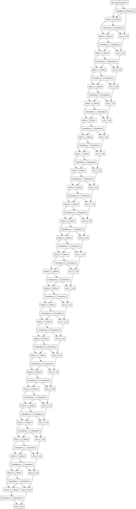

```python
# plot the model and inspect architecture
from tensorflow.keras.utils import plot_model
plot_model(model_7)
```

[figure not shown]

Let's save the best version of N-BEATS model.

```python
model_7.save(model_7.name)
```

```
INFO:tensorflow:Assets written to: model_7_N_BEATS\assets
```

[output not shown]

## Model 8: Creating an ensemble (stacking different model together)

Despite complexity of N-BEATS not working, its part of machine learning. Not everything will work.

We will look to combine multiple different models on the same problem. Ensembles are typical models to be seen on winning data science competitions on webslits like Kaggle.

[figure not shown]

*Example of the power of ensembling. One Daniel model makes a decision with a smart level of 7 but when a Daniel model teams up with multiple different people, together (ensembled) they make a decision with a smart level of 10. The key here is combining the decision power of people with different backgrounds, if you combined multiple Daniel models, you'd end up with an average smart level of 7. Note: smart level is not an actual measurement of decision making, it is for demonstration purposes only.*

The N-BEATS paper for example used and ensemble model of 180 in total. Which used different loss functions and window sizes.

Benfits of the ensemble is the `decision of the crowd effect`. Rather than relying on a single model, you can take the average or median of many different models. This doesn't work with similar models, as they would predict practically the same thing.

But even with deep learning models, retraining them can still give varied results due to the randomization of weights and biases every time it is retrained.

We will use a combination of:

- Different loss functions (MAE,MSE,MAPE)
- Randomly initialized models

We'll start with function creating, to produce a list of different models trained with different loss functions. Each layer in the ensemble models will be initialized with a random noram `(Gaussian) distribution` using `He normal initialization`. This'll help estimate the prediction intervals later on.

### Constructing and fitting an ensemble of models (using different loss functions)

```python
def get_ensemble_models(horizon=HORIZON,
                        train_data=train_dataset,
                        test_data=test_dataset,
                        num_iter=10,
                        num_epochs=100,
                        loss_fns=['mae','mse','mape']):
    '''
    Returns a list of num_iter models each trained on MAE, MSE, and MAPE loss.

    For example, if num_iter=10, a list of 30 trained models will be returned:
    10 * len(['mae','mse','mape'])
    '''
    # make empty list for trained ensemble models
    ensemble_models = []

    # create num_iter number of models per loss function
    for i in range(num_iter):
        # build and fit a new model with a different loss function
        for loss_function in loss_fns:
            print(f'Optimizing model by reducing: {loss_function} for {num_epochs} epochs, model number: {i}')

            # construct a simple model (similar to model_1)
            model = tf.keras.Sequential([
                # initialize layers with normal (gaussian distribution so we can use the model for prediction)
                # interval estimation later: https://www.tensorflow.org/api_docs/python/tf/keras/initializers/HeNormal
                layers.Dense(128,kernel_initializer='he_normal',activation='relu'),
                layers.Dense(128,kernel_initializer='he_normal',activation='relu'),
                layers.Dense(HORIZON)
            ])

            # compile simple model with current loss function
            model.compile(loss=loss_function,
                          optimizer=tf.keras.optimizers.Adam(),
                          metrics=['mae','mse'])

            # fit model
            model.fit(train_data,
                      epochs=num_epochs,
                      verbose=0,
                      validation_data=test_data,
                      # add callbacks to prevent training from going/stalling for too long
                      callbacks=[tf.keras.callbacks.EarlyStopping(monitor='val_loss',
                                                                  patience=200,
                                                                  restore_best_weights=True),
                                                                  tf.keras.callbacks.ReduceLROnPlateau(monitor='val_loss',
                                                                                                       patience=100,
                                                                                                       verbose=1)])

            # append fitted model to list of ensemble models
            ensemble_models.append(model)

    return ensemble_models # return list of trained models
```

The function is made :)

Let's try running with `num_iter=5` runs with 1000 epochs, resulting in 15 models (5 models per 3 loss functions).

> **Note**: You will generally find more total models mean better performance. Though it comes with tradeoff of having to train longer.

```python
%%time
# get list of trained ensemble models
ensemble_models = get_ensemble_models(num_iter=5,
                                      num_epochs=1000)
```

```
Optimizing model by reducing: mae for 1000 epochs, model number: 0

Epoch 292: ReduceLROnPlateau reducing learning rate to 0.00010000000474974513.

Epoch 775: ReduceLROnPlateau reducing learning rate to 1.0000000474974514e-05.

Epoch 875: ReduceLROnPlateau reducing learning rate to 1.0000000656873453e-06.
Optimizing model by reducing: mse for 1000 epochs, model number: 0

Epoch 300: ReduceLROnPlateau reducing learning rate to 0.00010000000474974513.

Epoch 400: ReduceLROnPlateau reducing learning rate to 1.0000000474974514e-05.
Optimizing model by reducing: mape for 1000 epochs, model number: 0

Epoch 149: ReduceLROnPlateau reducing learning rate to 0.00010000000474974513.

Epoch 664: ReduceLROnPlateau reducing learning rate to 1.0000000474974514e-05.

Epoch 764: ReduceLROnPlateau reducing learning rate to 1.0000000656873453e-06.
Optimizing model by reducing: mae for 1000 epochs, model number: 1

Epoch 452: ReduceLROnPlateau reducing learning rate to 0.00010000000474974513.

Epoch 778: ReduceLROnPlateau reducing learning rate to 1.0000000474974514e-05.

Epoch 878: ReduceLROnPlateau reducing learning rate to 1.0000000656873453e-06.
Optimizing model by reducing: mse for 1000 epochs, model number: 1

Epoch 525: ReduceLROnPlateau reducing learning rate to 0.00010000000474974513.

Epoch 625: ReduceLROnPlateau reducing learning rate to 1.0000000474974514e-05.
Optimizing model by reducing: mape for 1000 epochs, model number: 1

Epoch 159: ReduceLROnPlateau reducing learning rate to 0.00010000000474974513.

Epoch 259: ReduceLROnPlateau reducing learning rate to 1.0000000474974514e-05.
Optimizing model by reducing: mae for 1000 epochs, model number: 2
Optimizing model by reducing: mse for 1000 epochs, model number: 2

Epoch 563: ReduceLROnPlateau reducing learning rate to 0.00010000000474974513.
```

[output cut: 32 more lines]

```

Epoch 379: ReduceLROnPlateau reducing learning rate to 0.00010000000474974513.

Epoch 479: ReduceLROnPlateau reducing learning rate to 1.0000000474974514e-05.
Optimizing model by reducing: mape for 1000 epochs, model number: 4

Epoch 194: ReduceLROnPlateau reducing learning rate to 0.00010000000474974513.

Epoch 294: ReduceLROnPlateau reducing learning rate to 1.0000000474974514e-05.

Epoch 394: ReduceLROnPlateau reducing learning rate to 1.0000000656873453e-06.

Epoch 494: ReduceLROnPlateau reducing learning rate to 1.0000001111620805e-07.
CPU times: total: 10min 16s
Wall time: 5min 31s
```

Let's now write a function to use the list of trained ensemble models to make predictions and then return a list of predictions.

### Making predictions with an ensemble model

```python
# create a function which uses a list of trained models to make and return a list of predictions
def make_ensemble_preds(ensemble_models, data):
    ensemble_preds = []
    for model in ensemble_models:
        preds=model.predict(data)
        ensemble_preds.append(preds)
    return tf.constant(tf.squeeze(ensemble_preds))
```

```python
# create a list of ensemble predictions
ensemble_preds = make_ensemble_preds(ensemble_models=ensemble_models,
                                     data=test_dataset)
ensemble_preds
```

[output not shown]

[output not shown]

[output not shown]

[output not shown]

```
<tf.Tensor: shape=(15, 556), dtype=float32, numpy=
array([[ 8807.532 ,  8781.545 ,  8996.933 , ..., 49659.54  , 48499.855 ,
        46074.543 ],
       [ 8753.3125,  8780.523 ,  9096.304 , ..., 50098.    , 47785.95  ,
        46498.867 ],
       [ 8816.726 ,  8827.677 ,  9021.624 , ..., 50076.71  , 47879.258 ,
        46272.64  ],
       ...,
       [ 8774.006 ,  8816.54  ,  9138.37  , ..., 50385.023 , 48530.023 ,
        45538.45  ],
       [ 8701.789 ,  8810.834 ,  9144.14  , ..., 49885.35  , 47668.586 ,
        46393.04  ],
       [ 8753.207 ,  8742.788 ,  9042.831 , ..., 50114.23  , 48205.664 ,
        46107.523 ]], dtype=float32)>
```

With our ensemble predictions, we can evaluate with the ground truth with our 15 trained models. This means 15 sets of predictions, which we will take the median of combined results.

```python
# evaluate ensemble model(s) predictions
ensemble_results = evaluate_preds(y_true=y_test,
                                  y_pred=np.median(ensemble_preds,axis=0))
ensemble_results
```

```
{'mae': 571.64746,
 'mse': 1148349.9,
 'rmse': 1071.6108,
 'mape': 2.5806007,
 'mase': 1.0042262}
```

Ensemble still doesn't perform as good as naive sadly.

### Plotting the prediction intervals (uncertainty estimates) of our ensemble

The combined model only gives us a single point. What we could do is get a range of values for our `HORIZON`.

So for example, tomorrow's bitcoin price is `50,000 USD`. Maybe it could help by predicting tomorrow as a range between `48-50,000 USD`. Knowing said range can help make better decisions for the forecasts.

These are called **prediction intervals / uncertainty estimates**. Which are often as important as the forecast itself.

Why? Point predictions are almost wrong when predicting the future. So having a range to go off of, can help with decision making.

[figure not shown]

One way to achieve the 95% confidence prediction intervals for deep learning model is the bootstrap method:

```python
# find upper and lower bounds of ensemble predictions
def get_upper_lower(preds): # 1. take the predictions of multiple randomly initialized deep learning networks

    # 2. Measure the sd of the predictions
    std = tf.math.reduce_std(preds,axis=0)

    # 3. Multiply the sd by 1.96
    interval = 1.96 * std

    # 4. get the prediction interval for upper and lower
    preds_mean = tf.reduce_mean(preds,axis=0)
    lower,upper = preds_mean-interval, preds_mean+interval
    return lower,upper

# get the upper and lower bounds of the 95%
lower,upper = get_upper_lower(preds=ensemble_preds)
```

> But why is `1.96` = to 95% of std values?

This is due to the way distrubution shape works for such data. If you standardize a normal variable (mean = 0, std = 1), then:

- About 68% of values fall within ±1σ
- About 95% fall within ±1.96σ
- About 99.7% fall within ±3σ

Its often assuming that the std given of the data is symmetrical both pos and neg. If one side of the tail is a little fatter, this can indirectly create skewing for the deviation, so could be better to utilize a lower and upper bound percentile, than a hard factored value for both.

But in assuming this is gausian distribution, aka normal symmetrical distribution, often times `95%` of the value set within `1.96` std because of the shape of said distribution. Kind of like the golden ratio, or pi * diameter = circumference of circle.

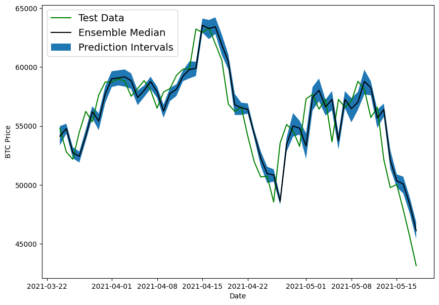

```python
# get the median values of our ensemble preds
ensemble_median = np.median(ensemble_preds, axis=0)

# plot median of ensemble preds along with the prediction intervals (where the predictions fall between)
offset=500
plt.figure(figsize=(10,7))
plt.plot(X_test.index[offset:],y_test[offset:],'g',label='Test Data')
plt.plot(X_test.index[offset:],ensemble_median[offset:],'k-',label='Ensemble Median')
plt.xlabel('Date')
plt.ylabel('BTC Price')
plt.fill_between(X_test.index[offset:],
                 (lower)[offset:],
                 (upper)[offset:],label='Prediction Intervals')
plt.legend(loc='upper left', fontsize=14)
```

So what can we make of the ensemble prediction plot?

It looks to lag prediction by day, almost one to one with our naive model, with std intervals being minute.

The indication of lagging data and low prediction intervals suggests **overfitting** of data. However we can test the overfitting hypothesis by allowing the model to predict in the future.

### Two types of uncertainty (coconut and subway)

You can't predict the future, but it doesnt mean that trying isn't valuable. Even more so with uncertainty estimates and prediction intervals like the one we did above.

Uncertainty estimates seek out to qualitatively and quantitively answer the questions:

- What can my model know? (with perfect data, what's possible to learn?)
- What doesn't my model know? (what can a model never predict?)

There are two types of uncertainty in machine learning you should be aware of:

- **Aleatoric uncertainty** - this type of uncertainty cannot be reduced. Referred as 'data' or 'subway' uncertainty.
  - Say train arrival time is supposedly 10:08am, but rarely arrives *exactly* 10:08am. Its usually plus/minus 1-2 minutes, or even 10 minutes if delay occurs. Even with all time data, uncertainty is still present.
  - When we measured prediction intervals, we were measuring a form of subway uncertainty for Bitcoin price predictions (a little either side of the point predictions).
- **Epistemic uncertainty** - this type of uncertainty can be reduced. Referred as 'model' or 'coconut' uncertainty - very hard to calculate.
  - The analogy for coconut uncertainty involves whether or not you'd get hit on the head by a coconut when going to a beach.
    - When at a beach with coconut trees, it is very hard to calculte how often would a coconut fall off a tree, and more so that it lands on top of you.
    - But uncertainty can be reduced to zero by going to a beach without coconuts (aka. collecting more data for your situation).
  - Model uncertainty can be reduced by collecting more data samples/building a model to capture different parameters about the data you're modelling.

Lines between the two are blurred - or exist in a sort of spectrum. Can be confusing, but important to keep in mind for any time series problem.

## Model 9: Train a model on full historical data, to make actual future predictions

To make predictions in the future, we'll train on full dataset and make predictions to some length of horizon.

Let's get the data ready.

```python
bitcoin_prices_windowed.head()
```

| Date | Price | block_reward | Price+1 | Price+2 | Price+3 | Price+4 | Price+5 | Price+6 | Price+7 |
| --- | --- | --- | --- | --- | --- | --- | --- | --- | --- |
| 2013-10-01 | 123.65499 | 25 | NaN | NaN | NaN | NaN | NaN | NaN | NaN |
| 2013-10-02 | 125.45500 | 25 | 123.65499 | NaN | NaN | NaN | NaN | NaN | NaN |
| 2013-10-03 | 108.58483 | 25 | 125.45500 | 123.65499 | NaN | NaN | NaN | NaN | NaN |
| 2013-10-04 | 118.67466 | 25 | 108.58483 | 125.45500 | 123.65499 | NaN | NaN | NaN | NaN |
| 2013-10-05 | 121.33866 | 25 | 118.67466 | 108.58483 | 125.45500 | 123.65499 | NaN | NaN | NaN |

```python
# train model on entire data to make predictions for the next day
X_all = bitcoin_prices_windowed.drop(['Price','block_reward'],axis=1).dropna().to_numpy()
y_all = bitcoin_prices_windowed.dropna()['Price'].to_numpy()
```

Let's turn them into performance optimized TF Datasets by:

1. Turning `X_all` and `y_all` into tensor Datasets using `tf.data.Dataset.from_tensor_slices()`
2. Combining the features and labels into a Dataset tuple using `tf.data.Dataset.zip()`
3. Batch and prefetch the data using `tf.data.Dataset.batch()` and `tf.data.Dataset.prefetch()` respectively

```python
# 1. Turn X and y into tensor Datasets
features_dataset_all = tf.data.Dataset.from_tensor_slices(X_all)
labels_dataset_all = tf.data.Dataset.from_tensor_slices(y_all)

# 2. Combine features and labels
dataset_all = tf.data.Dataset.zip((features_dataset_all, labels_dataset_all))

# 3. Batch and prefetch for optimal performance
BATCH_SIZE = 1024
dataset_all = dataset_all.batch(BATCH_SIZE).prefetch(tf.data.AUTOTUNE)

dataset_all
```

```
<_PrefetchDataset element_spec=(TensorSpec(shape=(None, 7), dtype=tf.float64, name=None), TensorSpec(shape=(None,), dtype=tf.float64, name=None))>
```

Let's create a model similar to `model_1` except with an extra layer. We'll also fit it to the entire dataset for 100 epochs.

```python
tf.random.set_seed(35)

# create model
model_9 = tf.keras.Sequential([
    layers.Dense(128, activation='relu'),
    layers.Dense(128, activation='relu'),
    layers.Dense(HORIZON)
])

# compile
model_9.compile(loss=tf.keras.losses.mae,
                optimizer=tf.keras.optimizers.Adam())

# fit model on all of the data to make future forecasts
model_9.fit(dataset_all,
epochs=100,
verbose=0)
```

```
<keras.src.callbacks.History at 0x1d08a369f90>
```

### Make predictions on the future

Let's start by defining a variable `INTO_FUTURE` which decides how many timesteps we'd like to predict into the future.

```python
# how many timesteps to predict into the future?
INTO_FUTURE = 14
```

[figure not shown]

*Example flow chart representing loop on creating forecasts. It is also important to retrain everytime new data is made - aka our problem of bitcoin price updating every day, you'd want to retrain every day as it provides a new concrete datapoint to use.*

Let's create function which returns `INTO_FUTURE` forecasted values using a trained model. The following steps are:

1. Function which takes as input:
   - a list of values (the Bitcoin historical data)
   - a trained model (such as `model_9`)
   - a window into the future to predict (our `INTO_FUTURE` variable)
   - the window size a model was trained on (`WINDOW_SIZE`) - the model can only predict on the same kind of data it was trained on
2. Creates an empty list for future forecasts, and extracts the last `WINDOW_SIZE` values from the input values (predictions will start from the last `WINDOW_SIZE` values of the training data)
3. Loop `INTO_FUTURE` times making a prediction on `WINDOW_SIZE` datasets which update to remove the first value and append the latest prediction

Eventually future predictions will be made using model's own predictions.

```python
# 1. create function to make predictions into the future
def make_future_forecast(values,model,into_future,window_size=WINDOW_SIZE) -> list:
    '''
    Makes future forecasts into_future steps after values ends.

    Returns future forecasts as list of floats.
    '''
    # 2. Make an empty list for future forecasts/prepare data to forecast on
    future_forecast = []
    last_window = values[-WINDOW_SIZE:] # only want preds from the last window (will be updated)

    # 3. Make INTO_FUTURE number of predictions, altering the data which gets predicted on wach time
    for _ in range(into_future):

        # predict on last window then append it again (model starts to make forecasts on its own with prev. forecast)
        future_pred = model.predict(tf.expand_dims(last_window,axis=0))
        print(f'Predicting on: \n {last_window} -> Prediction: {tf.squeeze(future_pred).numpy()}\n')

        # append predictions to future_forecast
        future_forecast.append(tf.squeeze(future_pred).numpy())
        # print(future_forecast)

        # update last window with new pred and get WINDOW_SIZE most recent preds (model was trained on WINDOW_SIZE windows)
        last_window = np.append(last_window,future_pred)[-WINDOW_SIZE:]

    return future_forecast
```

Time to bring in BitPredict to life and make future forecasts of the price of Bitcoin.

> **Exercise:** See if you can make our `make_future_forecasts()` train the model on every proceeding forecasts. Because the data that is generated is then unaccounted for.

```python
# make forecasts into future of the price of Bitcoin
future_forecast = make_future_forecast(values=y_all,
                                       model=model_9,
                                       into_future=INTO_FUTURE,
                                       window_size=WINDOW_SIZE)
```

```
Predicting on:
 [56573.5554719  52147.82118698 49764.1320816  50032.69313676
 47885.62525472 45604.61575361 43144.47129086] -> Prediction: 55021.61328125

Predicting on:
 [52147.82118698 49764.1320816  50032.69313676 47885.62525472
 45604.61575361 43144.47129086 55021.61328125] -> Prediction: 51282.91015625

Predicting on:
 [49764.1320816  50032.69313676 47885.62525472 45604.61575361
 43144.47129086 55021.61328125 51282.91015625] -> Prediction: 47374.75390625

Predicting on:
 [50032.69313676 47885.62525472 45604.61575361 43144.47129086
 55021.61328125 51282.91015625 47374.75390625] -> Prediction: 50058.5703125

Predicting on:
 [47885.62525472 45604.61575361 43144.47129086 55021.61328125
 51282.91015625 47374.75390625 50058.5703125 ] -> Prediction: 46396.00390625

Predicting on:
 [45604.61575361 43144.47129086 55021.61328125 51282.91015625
 47374.75390625 50058.5703125  46396.00390625] -> Prediction: 45013.16796875

Predicting on:
 [43144.47129086 55021.61328125 51282.91015625 47374.75390625
 50058.5703125  46396.00390625 45013.16796875] -> Prediction: 49833.828125

Predicting on:
 [55021.61328125 51282.91015625 47374.75390625 50058.5703125
 46396.00390625 45013.16796875 49833.828125  ] -> Prediction: 53081.265625

Predicting on:
 [51282.91015625 47374.75390625 50058.5703125  46396.00390625
 45013.16796875 49833.828125   53081.265625  ] -> Prediction: 48451.85546875

Predicting on:
 [47374.75390625 50058.5703125  46396.00390625 45013.16796875
 49833.828125   53081.265625   48451.85546875] -> Prediction: 48072.05859375

Predicting on:
 [50058.5703125  46396.00390625 45013.16796875 49833.828125
 53081.265625   48451.85546875 48072.05859375] -> Prediction: 48868.0859375

Predicting on:
 [46396.00390625 45013.16796875 49833.828125   53081.265625
 48451.85546875 48072.05859375 48868.0859375 ] -> Prediction: 45314.6875

Predicting on:
 [45013.16796875 49833.828125   53081.265625   48451.85546875
 48072.05859375 48868.0859375  45314.6875    ] -> Prediction: 47498.01171875

Predicting on:
 [49833.828125   53081.265625   48451.85546875 48072.05859375
 48868.0859375  45314.6875     47498.01171875] -> Prediction: 52028.59765625
```

```python
future_forecast[:10]
```

```
[55021.613,
 51282.91,
 47374.754,
 50058.57,
 46396.004,
 45013.168,
 49833.83,
 53081.266,
 48451.855,
 48072.06]
```

### Plot future forecasts

To plot our model's forecasts against the historica data of bitcoin, we'll need a series of future dates to make it plotable. We can create a function to return date range from a specified start date to a specified number of days into the future (`INTO_FUTURE`).

To do so, we'll use combination of NumPy's `datetime64` datatype, with NumPy's `timedelta64` method which helps to create date ranges.

```python
def get_future_dates(start_date,into_future,offset=1):
    '''
    Returns array of datetime values, ranging from start_date to start_date+horizon.

    start_date: date to start range (np.datetime64)
    into_future: number of days to add onto start date for range (int)
    offset: number of days to offset start_date by (default 1)
    '''

    start_date = start_date + np.timedelta64(offset,'D') # specify start date, 'D' stands for day
    end_date = start_date + np.timedelta64(into_future, 'D') # specify end date
    return np.arange(start_date,end_date,dtype='datetime64[D]') # return a date range between start date and end date
```

Start date of forecast dates, will be the last date of our dataset.

```python
# last timestep of timesteps (currently in np.datetime64 format)
last_timestep = bitcoin_prices.index[-1]
last_timestep
```

```
Timestamp('2021-05-18 00:00:00')
```

```python
# get next two weeks of timesteps
next_time_steps = get_future_dates(start_date=last_timestep,
                                   into_future=INTO_FUTURE)

next_time_steps
```

```
array(['2021-05-19', '2021-05-20', '2021-05-21', '2021-05-22',
       '2021-05-23', '2021-05-24', '2021-05-25', '2021-05-26',
       '2021-05-27', '2021-05-28', '2021-05-29', '2021-05-30',
       '2021-05-31', '2021-06-01'], dtype='datetime64[D]')
```

Now we have the future bitcoin dates, but have to make sure the lines of the plot connect (try not running the cell below and then plotting the data). Let's insert last timestep and its Bitcoin price of our training date to the `next_time_steps` and `future_forecast` arrays.

```python
# insert last timestep/final price so the graph doesn't look messed
next_time_steps = np.insert(next_time_steps, 0, last_timestep)
future_forecast = np.insert(future_forecast, 0, btc_price[-1])
next_time_steps, future_forecast
```

```
(array(['2021-05-18', '2021-05-19', '2021-05-20', '2021-05-21',
        '2021-05-22', '2021-05-23', '2021-05-24', '2021-05-25',
        '2021-05-26', '2021-05-27', '2021-05-28', '2021-05-29',
        '2021-05-30', '2021-05-31', '2021-06-01'], dtype='datetime64[D]'),
 array([43144.473, 55021.613, 51282.91 , 47374.754, 50058.57 , 46396.004,
        45013.168, 49833.83 , 53081.266, 48451.855, 48072.06 , 48868.086,
        45314.688, 47498.01 , 52028.598], dtype=float32))
```

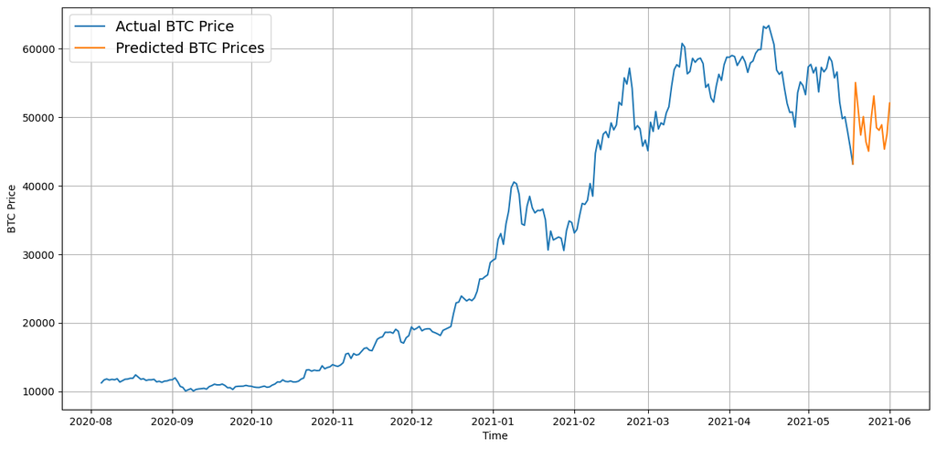

```python
# plot future price predictions of Bitcoin
plt.figure(figsize=(15,7))
plot_time_series(bitcoin_prices.index, btc_price, start=2500, format='-', label='Actual BTC Price')
plot_time_series(next_time_steps, future_forecast, format='-', label='Predicted BTC Prices')
```

It looks as if our prediction is running in a very cylical pattern, with predictable up and downs in the same sort of range. Essentially no better than random prediction.

Perhaps its due to model overfitting on training data, and not generalizing well to future data. Also you could figure out how the more forecasting it is doing, the more the errors will compound each other.

## Model 10: Why forecasting is BS (the turkey problem)

When creating any form of forecast, you must keep in mind the **turkey problem**. It's the analogy kept for data that fails to capture to future events, especially ones that catastrophically affect outcome.

Story goes with a turkey that lives a good life of 1000 days. Being fed and taken care of every day until the evening before thanksgiving. Based on the data, it seems like the turkey will continue to live a prestine point in life till forever, but human traditions over a certain point in date and time had other plans.

[figure not shown]

With our bitcoin problem, we could have built a model that predicted the values of it perfectly, but then some unknown and unpredictable reason plunges bitcoin 50% of its original values with no reason.

To get specific with how the turkey problem affects us, let's manufacture highly unlikely data points into the historical price of bitcoin - the price falling by x100 in a day.

```python
# lets introduce a turkey problem to our BTC data
btc_price_turkey = btc_price.copy()
btc_price_turkey[-1] = btc_price_turkey[-1] / 100
```

```python
# Manufacture an extra price on the end
btc_price_turkey[-10:]
```

```
[58788.2096789273,
 58102.1914262342,
 55715.5466512869,
 56573.5554719043,
 52147.8211869823,
 49764.1320815975,
 50032.6931367648,
 47885.6252547166,
 45604.6157536131,
 431.44471290860304]
```

```python
# get the timesteps for the turkey problem
btc_timesteps_turkey = np.array(bitcoin_prices.index)
btc_timesteps_turkey[-10:]
```

```
array(['2021-05-09T00:00:00.000000000', '2021-05-10T00:00:00.000000000',
       '2021-05-11T00:00:00.000000000', '2021-05-12T00:00:00.000000000',
       '2021-05-13T00:00:00.000000000', '2021-05-14T00:00:00.000000000',
       '2021-05-15T00:00:00.000000000', '2021-05-16T00:00:00.000000000',
       '2021-05-17T00:00:00.000000000', '2021-05-18T00:00:00.000000000'],
      dtype='datetime64[ns]')
```

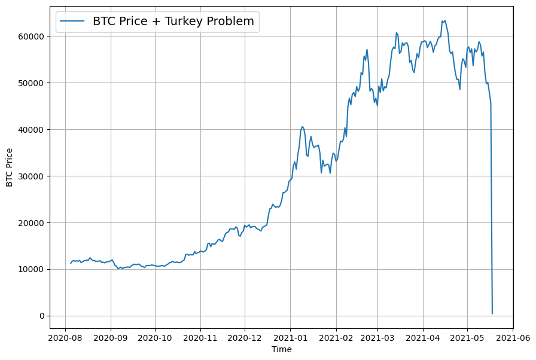

```python
plt.figure(figsize=(10,7))
plot_time_series(timesteps=btc_timesteps_turkey,
                 values=btc_price_turkey,
                 format='-',
                 label='BTC Price + Turkey Problem',
                 start=2500)
```

Let's check model performance wit this new data. Before that, let's create some windowed datasets with our turkey data.

```python
# create train and test sets for turkey problem data
full_windows, full_labels = make_windows(np.array(btc_price_turkey), window_size=WINDOW_SIZE,horizon=HORIZON)
len(full_windows),len(full_labels)

X_train,X_test,y_train,y_test = make_train_test_splits(full_windows,full_labels)
len(X_train),len(X_test),len(y_train),len(y_test)
```

```
(2224, 556, 2224, 556)
```

### Building a turkey model, to predict on turkey data

With the updated data, let's see the effects on 1 changed value.

To keep things comparable, we'll create a `turkey_model` that is a clone of `model_1`. So during evaluation, we can compare the `turkey_model` results to `model_1` results, seeing how 1 single data point can influence performance.

```python
# clone model 1 architecture for turkey model and fit the turkey model on the turkey data
turkey_model = tf.keras.models.clone_model(model_1)
turkey_model._name = 'Turkey_Model'
turkey_model.compile(loss='mae',
                     optimizer=tf.keras.optimizers.Adam())

turkey_model.fit(X_train,y_train,
                 epochs=100,
                 verbose=0,
                 validation_data=(X_test,y_test),
                 callbacks=[create_model_checkpoint(turkey_model.name)])
```

```
INFO:tensorflow:Assets written to: model_experiments\Turkey_Model\assets
```

[output not shown]

[output not shown]

[output not shown]

[output not shown]

[output not shown]

[output not shown]

[output not shown]

[output not shown]

[output not shown]

[output not shown]

[output not shown]

[output not shown]

[output not shown]

[output not shown]

[output not shown]

[output not shown]

[output not shown]

[output not shown]

[output not shown]

[output not shown]

[output not shown]

[output not shown]

[output not shown]

[output not shown]

[output not shown]

[output not shown]

[output not shown]

[output not shown]

[output not shown]

[output not shown]

[output not shown]

[output not shown]

[output not shown]

[output not shown]

[output not shown]

```
<keras.src.callbacks.History at 0x1d092ca18a0>
```

```python
# evaluate turkey model on test data
turkey_model.evaluate(X_test,y_test)
```

```
730.8286743164062
```

```python
# load best model and evaluate on test data
turkey_model = tf.keras.models.load_model('model_experiments/Turkey_Model/')
turkey_model.evaluate(X_test,y_test)
```

```
641.6259155273438
```

```python
# make predictions with turkey model
turkey_preds = make_preds(turkey_model,X_test)
turkey_preds[:10]
```

```
<tf.Tensor: shape=(10,), dtype=float32, numpy=
array([8800.52 , 8754.668, 9041.104, 8740.544, 8733.108, 8726.307,
       8656.957, 8501.656, 8441.961, 8521.796], dtype=float32)>
```

```python
# evaluate turkey preds
turkey_results = evaluate_preds(y_true=y_test,
                                y_pred=turkey_preds)

turkey_results
```

```
{'mae': 17144.766,
 'mape': 121.58286,
 'mase': 26.53158,
 'mse': 615487800.0,
 'rmse': 23743.305}
```

```python
model_1_results
```

```
{'mae': 564.84296,
 'mse': 1150266.8,
 'rmse': 1072.5049,
 'mape': 2.5312698,
 'mase': 0.9922726}
```

Model form turkey performs a lot worse. We can then visualize it on a graph.

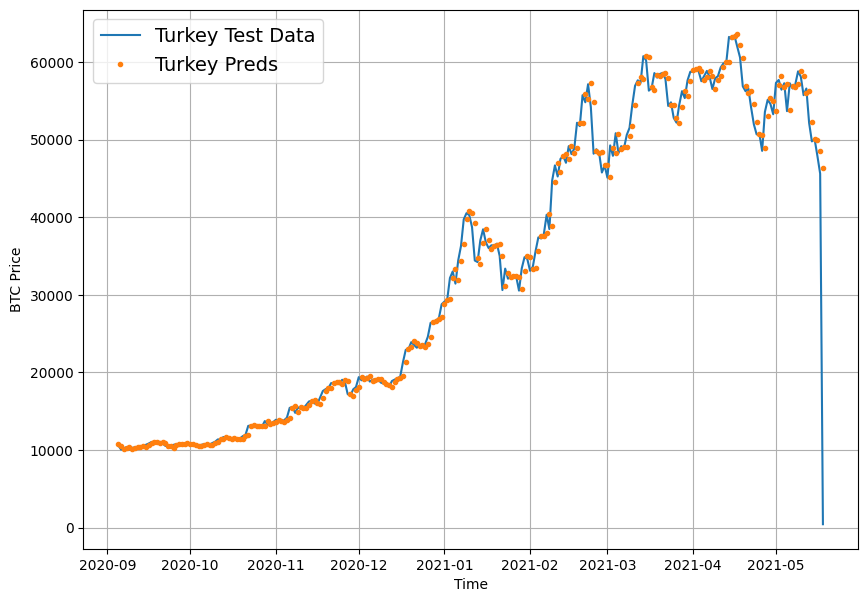

```python
plt.figure(figsize=(10, 7))
# plot_time_series(timesteps=btc_timesteps_turkey[:split_size], values=btc_price_turkey[:split_size], label="Train Data")
offset=300
plot_time_series(timesteps=btc_timesteps_turkey[-len(X_test):],
                 values=btc_price_turkey[-len(y_test):],
                 format="-",
                 label="Turkey Test Data", start=offset)
plot_time_series(timesteps=btc_timesteps_turkey[-len(X_test):],
                 values=turkey_preds,
                 label="Turkey Preds",
                 start=offset);
```